# fdaSP: sparse regression from vectors to functions

Mauro Bernardi

A practical guide to penalized linear regression, locally sparse coefficient curves, and locally sparse coefficient surfaces. Examples use the public API of **fdaSP 1.1.3 with the accompanying development corrections**, with reproducible data, regularization paths, model selection and prediction.

# 1 Linear regression and regularization paths

## 1.1 Prepare the session

Run the examples in chapter order, or use the downloadable R script. These helpers define solver tolerances, reshape path matrices for plotting, and check convergence. Subsequent chapters reuse them.

```r
library(fdaSP)
library(ggplot2)
theme_set(theme_minimal(base_size=12)+theme(legend.position="bottom"))
ctl <- list(maxit=3000, abstol=1e-6, reltol=1e-6, print.out=FALSE)
path_data <- function(path, lambda) {
  path <- as.matrix(path)
  stopifnot(nrow(path)==length(lambda))
  data.frame(lambda=rep(lambda,ncol(path)), coefficient=as.vector(path),
             term=factor(rep(seq_len(ncol(path)),each=nrow(path))))
}
check_path <- function(fit) {
  stopifnot(all(is.finite(fit$sp.coef.path)), all(fit$convergence==1))
}
```

## 1.2 Start with a sparse signal

`lmSP()` fits a path; `lmSP_cv()` selects a tuning parameter by cross-validation. The same interface covers Lasso, Group Lasso, sparse Group Lasso and their overlapping-group counterparts. We begin with 12 predictors and three nonzero coefficients, so that the fitted path can be compared with a known signal.

```r
set.seed(101)
n <- 100
p <- 12
X <- matrix(rnorm(n*p), n, p)
beta <- c(2,-1,1,rep(0,p-3))
y <- drop(X %*% beta) + rnorm(n)
lambda <- 10^seq(0.7,-2,length.out=30)
control <- ctl
```

The grid is decreasing and equally spaced on a logarithmic scale. We set `standardize.data=FALSE` explicitly: the simulated predictors already have comparable scales, and predictions below then use the original design directly. On real data, learn centering and scaling from the training sample and reuse them for validation and prediction. An unpenalized intercept can be requested with `intercept=TRUE`; other unpenalized covariates can be supplied through `Z`.

```r
fit <- lmSP(X=X, y=y, penalty="LASSO", lambda=lambda,
            standardize.data=FALSE, intercept=FALSE, control=control)
check_path(fit)
dim(fit$sp.coef.path)
```

```
## [1] 30 12
```

Each **row** of `sp.coef.path` corresponds to a value of `lambda`; each column corresponds to a predictor. This orientation matters when calculating predictions.

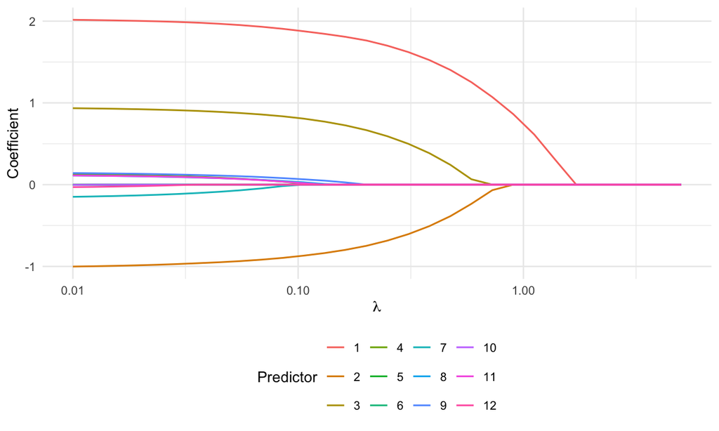

Lasso coefficient paths. The horizontal axis is logarithmic; each line is one predictor.

```r
ggplot(path_data(fit$sp.coef.path,fit$lambda),
       aes(lambda,coefficient,colour=term)) + geom_line(linewidth=.65) +
  scale_x_log10() + labs(x=expression(lambda),y="Coefficient",colour="Predictor")
```

## 1.3 Select a model and predict

The path object’s `lambda.min` minimizes **training MSE**. It is not the cross-validation choice. Use the CV result to select a row of the path, or refit at the selected value. The example splits observations into folds, appropriate for independent sampling; time-series examples need a different split.

```r
set.seed(102)
cv <- lmSP_cv(X=X, y=y, penalty="LASSO", lambda=fit$lambda,
              cv.fold=5, standardize.data=FALSE, control=control)
i_cv <- which.min(abs(fit$lambda-cv$lambda.min))
beta_cv <- as.numeric(fit$sp.coef.path[i_cv,])
Xnew <- matrix(rnorm(40*p),40,p)
ynew <- drop(Xnew %*% beta) + rnorm(40)
pred <- drop(Xnew %*% beta_cv)
data.frame(lambda=cv$lambda.min, test_MSE=mean((ynew-pred)^2))
```

```
##     lambda test_MSE
## 1 0.130991 1.042146
```

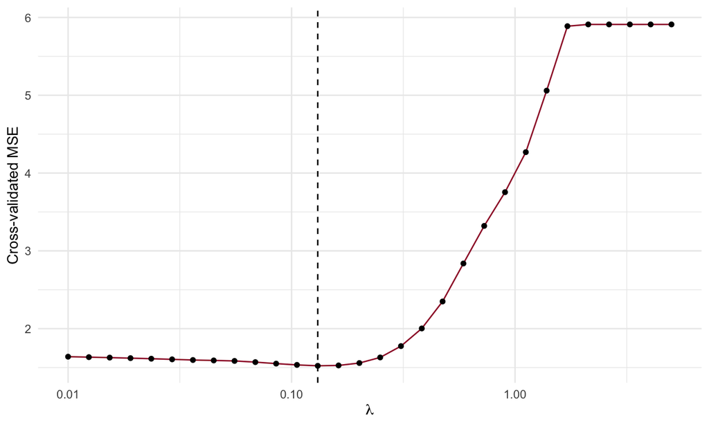

Cross-validated prediction error and the selected tuning parameter.

```r
ggplot(data.frame(lambda=cv$lambda,mse=as.numeric(cv$mse)),aes(lambda,mse)) +
  geom_line(colour="#9e1b32") + geom_point(size=1.5) +
  geom_vline(xintercept=cv$lambda.min,linetype=2) + scale_x_log10() +
  labs(x=expression(lambda),y="Cross-validated MSE")
```

## 1.4 Compare the five penalty families

Disjoint groups are encoded by a membership vector. For overlapping groups, use a list whose `groups` element concatenates the member indices and whose `Glen` element records the length of each group. A predictor may appear more than once in the concatenated vector.

```r
groups <- rep(1:4,each=3)
overlap <- list(groups=c(1:4,4:7,7:10,10:12),Glen=c(4,4,4,3))
family_args <- list(
  LASSO=list(),
  GLASSO=list(groups=groups),
  spGLASSO=list(groups=groups,alpha=.5),
  OVGLASSO=list(groups=overlap),
  spOVGLASSO=list(groups=overlap,alpha=.5))
fits <- lapply(names(family_args),function(method) {
  do.call(lmSP,c(list(X=X,y=y,penalty=method,lambda=lambda,
                     standardize.data=FALSE,control=control),family_args[[method]]))
})
names(fits) <- names(family_args)
invisible(lapply(fits,check_path))
paths <- do.call(rbind,lapply(names(fits),function(method) {
  d <- path_data(fits[[method]]$sp.coef.path,fits[[method]]$lambda)
  d$method <- method
  d
}))
```

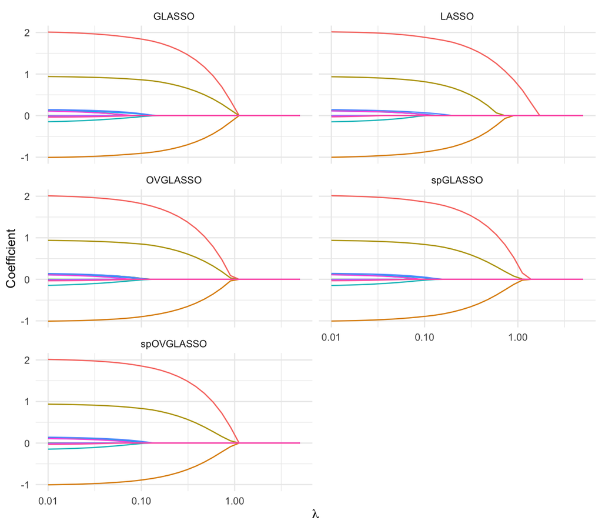

Coefficient paths under five penalties, using the same response and tuning grid. Equal numerical tuning parameters do not imply equal penalty strength across methods.

```r
ggplot(paths,aes(lambda,coefficient,group=term,colour=term)) +
  geom_line(linewidth=.55) + scale_x_log10() + facet_wrap(~method,ncol=2) +
  labs(x=expression(lambda),y="Coefficient") + theme(legend.position="none")
```

Group Lasso selects groups, whereas sparse Group Lasso also allows within-group sparsity (Yuan and Lin 2006; Simon et al. 2013). Overlapping groups express shared structure; the penalty acts on repeated group memberships rather than on a partition (Jenatton, Audibert, and Bach 2011).

## 1.5 Adaptive penalties

For Lasso, `adaptive=TRUE` requests the package’s adaptive scheme. For group penalties, the example below supplies explicit pilot-based **group weights**. These are distinct from `var_weights`, which act on individual coefficients. In the supplied version, the `lmSP()` group branches do not forward `weights_adaptive` to their solvers, so explicit weights make the intended penalty unambiguous.

```r
adaptive_lasso <- lmSP(X=X,y=y,penalty="LASSO",adaptive=TRUE,
                       lambda=lambda,standardize.data=FALSE,control=control)
pilot <- drop(qr.solve(X,y))
pilot_norms <- vapply(split(pilot,groups),function(b) sqrt(sum(b^2)),numeric(1))
group_weights <- 1/pmax(pilot_norms,1e-4)
adaptive_group <- lmSP(X=X,y=y,penalty="GLASSO",groups=groups,
                       group_weights=group_weights,lambda=lambda,
                       standardize.data=FALSE,control=control)
check_path(adaptive_lasso)
check_path(adaptive_group)
```

The floor `1e-4` is an explicit numerical choice for this example, not an identity for inverse weights at zero. Pilot weights are data dependent (Zou 2006). When evaluating an adaptive procedure by CV, recompute its pilot and weights inside each training fold; supplying full-sample weights to an ordinary CV call does not do this automatically.

## 1.6 Inspect degrees of freedom along the path

The tested version returns `dof` and `bic` for Lasso and Group Lasso. The sparse-group and overlapping-group fits do not currently return these components. The plot includes only fits for which a DoF vector is actually returned; it does not replace missing values by a count of nonzero coefficients. For the explicit pilot-weighted Group Lasso example above, the group solver reports a fixed-weight contribution, not the full correction for data-dependent weights.

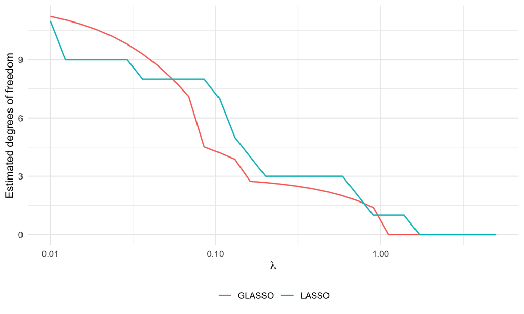

Degrees-of-freedom estimates returned by fdaSP along the available fitted paths.

```r
dof_methods <- names(fits)[vapply(fits,function(z) !is.null(z$dof),logical(1))]
df_paths <- do.call(rbind,lapply(dof_methods,function(method) {
  z <- fits[[method]]
  stopifnot(length(z$dof)==length(z$lambda))
  data.frame(lambda=z$lambda,dof=as.numeric(z$dof),method=method)
}))
ggplot(df_paths,aes(lambda,dof,colour=method)) + geom_line(linewidth=.7) +
  scale_x_log10() + labs(x=expression(lambda),y="Estimated degrees of freedom",colour=NULL)
```

# 2 Scalar-on-function regression

## 2.1 From predictor curves to a coefficient curve

For subject $i$, the model relates a scalar response to a predictor curve:

$$y_i=\int_0^1 x_i(t)\psi(t)\,\mathrm dt+\varepsilon_i,
\qquad \psi(t)=\boldsymbol\varphi(t)^\top\boldsymbol\psi.$$

`f2sSP()` represents the coefficient function with B-splines and imposes an overlapping-group penalty on the basis coefficients. Local support of the basis makes it possible to estimate regions where the coefficient function is zero. Here the curve has eight basis coefficients, of which three are nonzero.

**Grid convention.** The current implementation forms `mX %*% H`, where `H` contains basis values, without adding quadrature weights. We therefore multiply the sampled predictor curves by trapezoidal weights **before fitting**. The same weighted matrix is used for simulation and prediction. This makes the matrix product approximate the displayed integral rather than an unscaled sum.

```r
set.seed(201)
n_fun <- 80
t <- seq(0,1,length.out=41)
H <- splines::bs(t,df=8,intercept=TRUE)
curve_scores <- matrix(rnorm(n_fun*8),n_fun,8)
X_curves <- curve_scores %*% t(H)
qweight <- c(.5,rep(1,length(t)-2),.5)*diff(t)[1]
X_quad <- sweep(X_curves,2,qweight,"*")
psi_true <- drop(H %*% c(0,0,2,2,-1,0,0,0))
y_fun <- drop(X_quad %*% psi_true) + rnorm(n_fun,sd=.08)
```

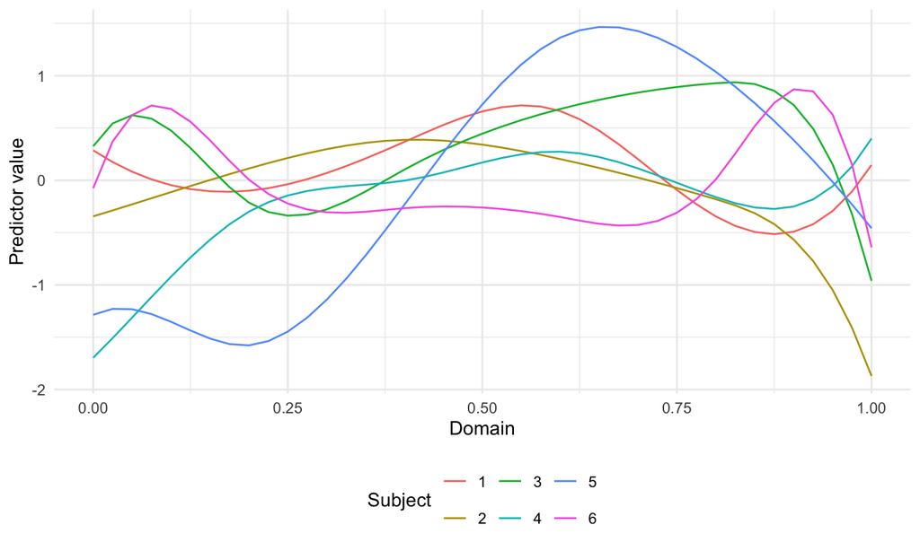

Six predictor curves before quadrature weighting.

```r
curves <- data.frame(t=rep(t,6),x=as.vector(t(X_curves[1:6,])),
                     subject=factor(rep(1:6,each=length(t))))
ggplot(curves,aes(t,x,colour=subject)) + geom_line() +
  labs(x="Domain",y="Predictor value",colour="Subject")
```

## 2.2 Fit and select the curve

We use cubic B-splines (`splOrd=4`) on the package’s equally spaced grid on $[0,1]$. The input rows represent subjects, not time points. The package’s CV routine splits subjects; it does not split individual points from a curve.

```r
scalar_fit <- f2sSP(vY=y_fun,mX=X_quad,M=8,splOrd=4,
                    nlambda1=25,lambda1.min.ratio=.001,
                    standardize.data=FALSE,control=control)
check_path(scalar_fit)
set.seed(202)
scalar_cv <- f2sSP_cv(vY=y_fun,mX=X_quad,M=8,splOrd=4,
                      lambda1=scalar_fit$lambda1,cv.fold=5,
                      standardize.data=FALSE,control=control)
i_scalar <- which.min(abs(scalar_fit$lambda1-scalar_cv$lambda1.min.mse))
psi_est <- drop(H %*% scalar_fit$sp.coef.path[i_scalar,])
stopifnot(max(abs(psi_est-scalar_fit$sp.fun.path[i_scalar,]))<1e-8)
```

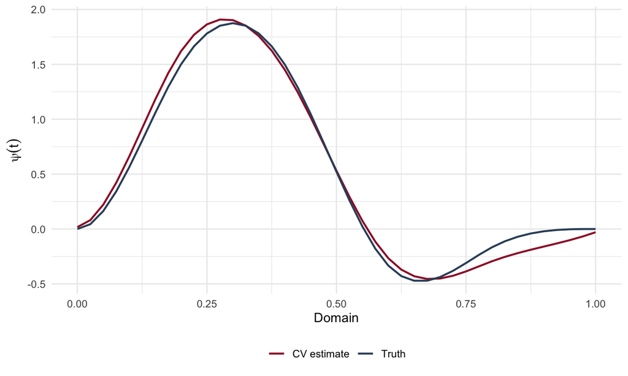

True coefficient curve and the estimate selected by subject-level cross-validation.

```r
curve_comparison <- data.frame(t=rep(t,2),value=c(psi_true,psi_est),
                               curve=rep(c("Truth","CV estimate"),each=length(t)))
ggplot(curve_comparison,aes(t,value,colour=curve)) + geom_line(linewidth=.85) +
  scale_colour_manual(values=c("CV estimate"="#9e1b32","Truth"="#334e68")) +
  labs(x="Domain",y=expression(psi(t)),colour=NULL)
```

## 2.3 Follow the path and predict new responses

`sp.coef.path` stores basis coefficients, while `sp.fun.path` stores the corresponding function values. Examining both separates coefficient shrinkage from changes in the shape of the regression function.

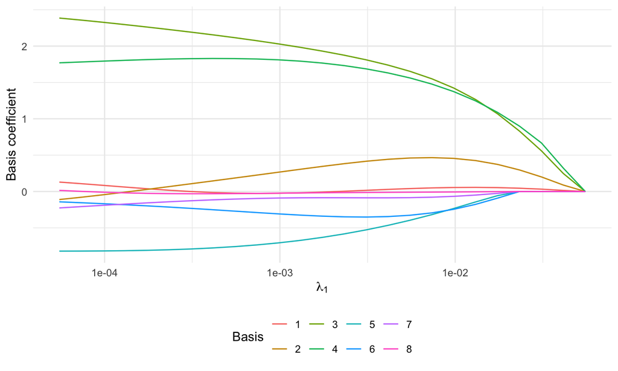

Basis-coefficient paths for the scalar-on-function model.

```r
ggplot(path_data(scalar_fit$sp.coef.path,scalar_fit$lambda1),
       aes(lambda,coefficient,colour=term)) + geom_line() + scale_x_log10() +
  labs(x=expression(lambda[1]),y="Basis coefficient",colour="Basis")
```

```r
set.seed(203)
Xnew_curves <- matrix(rnorm(30*8),30,8) %*% t(H)
Xnew_quad <- sweep(Xnew_curves,2,qweight,"*")
ynew_fun <- drop(Xnew_quad %*% psi_true)+rnorm(30,sd=.08)
pred_fun <- drop(Xnew_quad %*% psi_est)
data.frame(test_MSE=mean((ynew_fun-pred_fun)^2),
           curve_integrated_squared_error=sum(qweight*(psi_est-psi_true)^2))
```

```
##      test_MSE curve_integrated_squared_error
## 1 0.007965336                    0.006860105
```

## 2.4 Degrees of freedom, BIC and smoothing

`lambda1.min.bic` selects the BIC minimum; `lambda1.min.mse` selects the training-MSE minimum. Neither name denotes the CV optimum. The implementation computes BIC as $n\log(\mathrm{MSE})+\log(n)\widehat{\mathrm{df}}$; plot both components to understand the trade-off. Selecting a tuning parameter on the same data introduces a further layer of model selection.

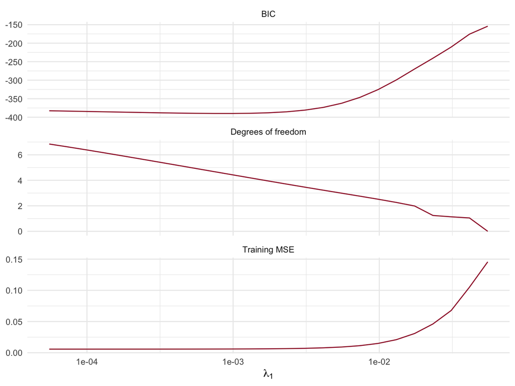

Training error, BIC and the returned degrees-of-freedom estimate across the scalar-on-function path.

```r
scalar_diagnostics <- data.frame(lambda=rep(scalar_fit$lambda1,3),
 value=c(scalar_fit$mse,scalar_fit$bic,scalar_fit$dof),
 measure=rep(c("Training MSE","BIC","Degrees of freedom"),each=length(scalar_fit$lambda1)))
ggplot(scalar_diagnostics,aes(lambda,value)) + geom_line(colour="#9e1b32") +
 scale_x_log10() + facet_wrap(~measure,scales="free_y",ncol=1) +
 labs(x=expression(lambda[1]),y=NULL)
```

The optional `lambda2` controls a finite-difference roughness penalty. With several smoothing values, output dimensions gain an additional grid axis. Always inspect `dim()` before selecting a slice.

```r
smooth_fit <- f2sSP(vY=y_fun,mX=X_quad,M=8,lambda1=scalar_fit$lambda1,
                    lambda2=c(.001,.01),diff_order=2,
                    standardize.data=FALSE,control=control)
check_path(smooth_fit)
dim(smooth_fit$sp.coef.path)
```

```
## [1] 25  2  8
```

This example uses fixed weights. `f2sSP()` also offers `weights_adaptive=TRUE`; its CV companion has a different signature, so adaptive validation should be constructed explicitly with training-fold pilots.

# 3 Function-on-function regression

## 3.1 A locally sparse coefficient surface

A functional response depends on a functional predictor through a surface:

$$y_i(s)=\int_0^1 x_i(t)\psi(t,s)\,\mathrm dt+\varepsilon_i(s),
\qquad
\psi(t,s)=\boldsymbol\varphi(t)^\top\boldsymbol\Psi\boldsymbol\theta(s).$$

The $M\times L$ coefficient matrix connects predictor-domain and response-domain basis functions. Locally sparse function-on-function regression uses an overlapping-group penalty adapted to this tensor-product basis (Bernardi, Canale, and Stefanucci 2023). The example uses $M=8$, $L=5$ and a surface supported on only part of the domain.

We retain the predictor curves and quadrature convention from the previous chapter. In this version of `f2fSP()`, both basis grids are constructed from the number of columns of `mX`; use the same grid length for predictor and response in this workflow.

```r
set.seed(301)
Theta <- splines::bs(t,df=5,intercept=TRUE)
Psi_true <- matrix(0,8,5)
Psi_true[3:4,2:3] <- 2
surface_true <- H %*% Psi_true %*% t(Theta)
Y_curves <- X_quad %*% surface_true +
  matrix(rnorm(n_fun*length(t),sd=.04),n_fun,length(t))
```

## 3.2 Estimate the surface and choose the tuning parameter

```r
surface_fit <- f2fSP(mY=Y_curves,mX=X_quad,M=8,L=5,
                     nlambda=20,lambda.min.ratio=.001,
                     standardize.data=FALSE,control=control)
check_path(surface_fit)
set.seed(302)
surface_cv <- f2fSP_cv(mY=Y_curves,mX=X_quad,M=8,L=5,
                       lambda=surface_fit$lambda,cv.fold=5,
                       standardize.data=FALSE,control=control)
i_surface <- which.min(abs(surface_fit$lambda-surface_cv$lambda.min))
Psi_est <- surface_fit$sp.coef.path[i_surface,,]
surface_est <- H %*% Psi_est %*% t(Theta)
stopifnot(max(abs(surface_est-surface_fit$sp.fun.path[i_surface,,]))<1e-8)
```

We reconstruct the selected surface explicitly from `sp.coef.path`, whose first dimension indexes the tuning parameter. This also makes the predictor and response axes unambiguous.

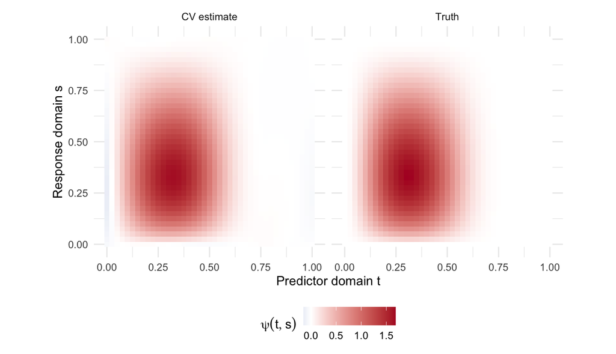

True and estimated coefficient surfaces on a common colour scale. Horizontal coordinates index the predictor domain; vertical coordinates index the response domain.

```r
surface_plot <- rbind(
  transform(expand.grid(t=t,s=t),value=as.vector(surface_true),panel="Truth"),
  transform(expand.grid(t=t,s=t),value=as.vector(surface_est),panel="CV estimate"))
ggplot(surface_plot,aes(t,s,fill=value)) + geom_raster() + coord_equal() +
  facet_wrap(~panel) + scale_fill_gradient2(low="#2166ac",mid="white",high="#b2182b") +
  labs(x="Predictor domain t",y="Response domain s",fill=expression(psi(t,s)))
```

## 3.3 Examine the path and predict curves

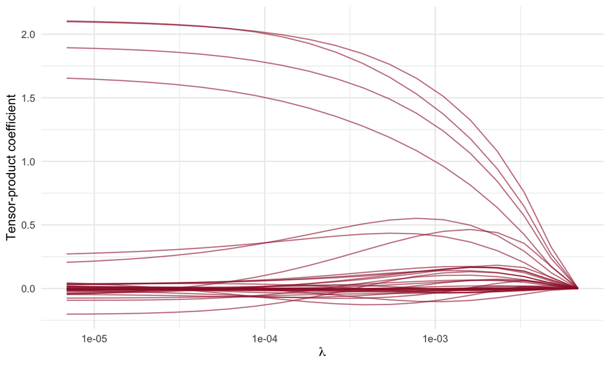

Tensor-product coefficient paths; the first array dimension indexes the regularization parameter.

```r
surface_path_matrix <- matrix(surface_fit$sp.coef.path,
                               nrow=length(surface_fit$lambda))
ggplot(path_data(surface_path_matrix,surface_fit$lambda),
       aes(lambda,coefficient,group=term)) + geom_line(colour="#9e1b32",alpha=.6) +
  scale_x_log10() + labs(x=expression(lambda),y="Tensor-product coefficient")
```

```r
set.seed(303)
Ynew <- Xnew_quad %*% surface_true +
  matrix(rnorm(nrow(Xnew_quad)*length(t),sd=.04),nrow(Xnew_quad),length(t))
Ypred <- Xnew_quad %*% surface_est
subject <- 1
curve_prediction <- data.frame(s=rep(t,2),value=c(Ynew[subject,],Ypred[subject,]),
                                curve=rep(c("Observed","Predicted"),each=length(t)))
mean((Ynew-Ypred)^2)
```

```
## [1] 0.001580285
```

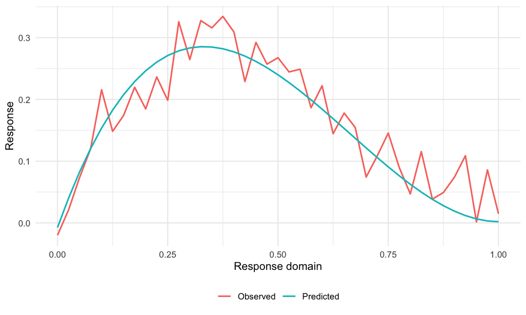

Observed and predicted response for a held-out subject.

```r
ggplot(curve_prediction,aes(s,value,colour=curve)) + geom_line(linewidth=.8) +
  labs(x="Response domain",y="Response",colour=NULL)
```

Prediction error and recovery of the coefficient surface answer different questions. A correlated functional design can predict well without uniquely recovering every feature of a surface. The test subjects above are separate from the subjects used for fitting and CV. `f2fSP()` does not return a `dof` component in the supplied version; this guide does not substitute a count of nonzero basis coefficients for a functional degrees-of-freedom formula.

# 4 Inflation: the complete model-comparison workflow

## 4.1 The data and the scope of the comparison

This chapter develops the inflation analysis in the original repository: correlations, ordinary least squares, Lasso and Elastic Net, best-subset selection, adaptive penalties, Bayesian model averaging, and the `fdaSP` implementation. The one-lag specification uses 18 macroeconomic predictors; the four-lag specification uses all 72 predictor columns.

These are full-sample model-comparison exercises. Random-fold cross-validation is retained from the original workflow and must not be interpreted as a real-time forecasting assessment. The separate chronological analysis later in this guide uses training, validation and test periods.

The repository relates the data to the inflation application discussed by Bernardi et al. (2024). We retain the supplied transformations rather than reconstructing them from raw economic series. Inspecting the supplied file reveals **125 observations, from July 1991 to July 2022**. The older prose mentioned 2023-Q4, but that endpoint is not present in this data file. The response used below is `CPIAUCSL`; `CPILFESL`, mentioned in the old introduction, is not a column in this version of the dataset.

```r
library(fdaSP)
library(ggplot2)
stopifnot(all(vapply(c("glmnet","leaps","BMS","corrplot"),
                    requireNamespace,logical(1),quietly=TRUE)))
original_data <- new.env()
load("../data/inflation-Q.RData",envir=original_data)
inflation <- original_data$infl.data
y_original <- as.numeric(inflation$CPIAUCSL)
lag1_names <- grep("_l1$",names(inflation),value=TRUE)
all_lag_names <- grep("_l[1-4]$",names(inflation),value=TRUE)
X1 <- as.matrix(inflation[,lag1_names])
X4 <- as.matrix(inflation[,all_lag_names])
stopifnot(ncol(X1)==18L,ncol(X4)==72L,
          all(is.finite(X4)),all(is.finite(y_original)))
data.frame(observations=nrow(inflation),first=min(inflation$DATE),
           last=max(inflation$DATE),one_lag=ncol(X1),four_lags=ncol(X4))
```

```
##   observations   first    last one_lag four_lags
## 1          125 1991-07 2022-07      18        72
```

All results and figures below are regenerated by the guide. The packages `glmnet`, `leaps`, `BMS` and `corrplot` are additional dependencies of this application, not additional dependencies imposed on `fdaSP` itself.

## 4.2 Preliminary correlations and one-lag OLS

As in the original example, the correlation plot uses inflation and the first lag of each macroeconomic indicator. Standardization does not change these correlations. Ellipses reveal both their sign and strength.

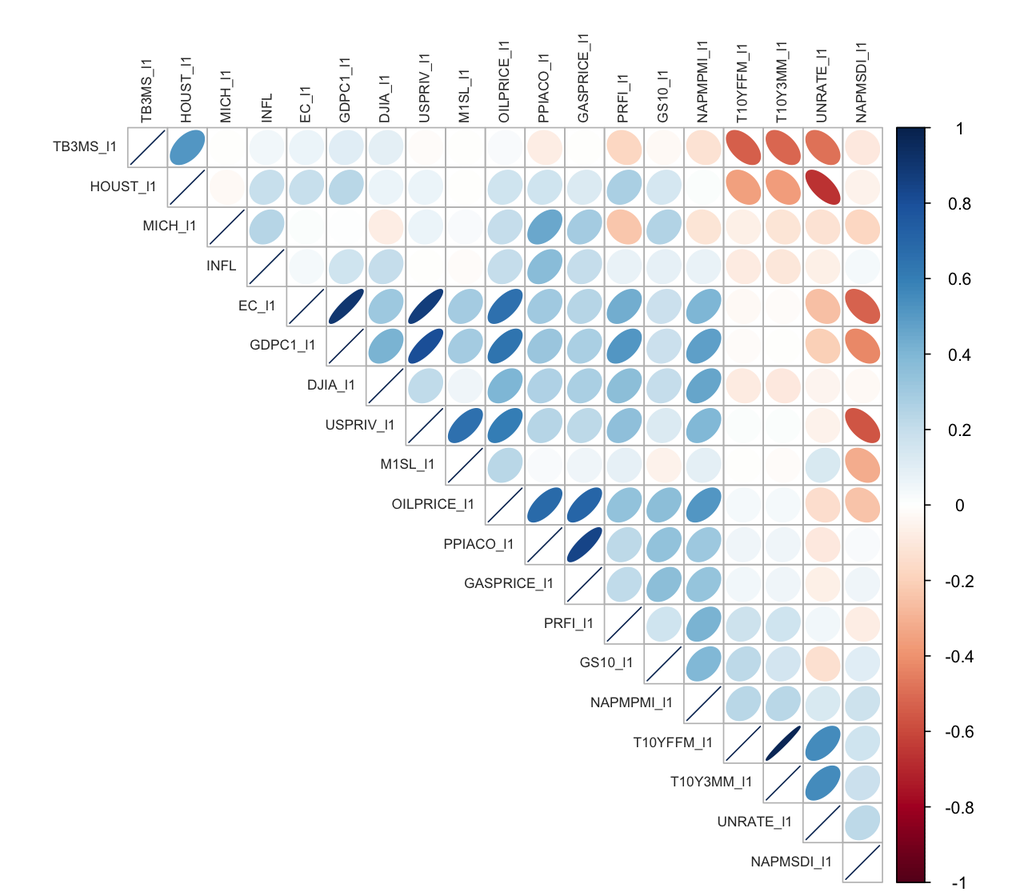

Inflation and the 18 first-lag macroeconomic predictors. Variables are ordered by the angular order of eigenvectors (AOE), as in the original analysis.

```r
X1_scaled <- scale(X1)
y_original_scaled <- drop(scale(y_original))
correlation_data <- cbind(INFL=y_original_scaled,X1_scaled)
correlation_matrix <- cor(correlation_data)
corrplot::corrplot(correlation_matrix,order="AOE",method="ellipse",
                   type="upper",tl.cex=.65,tl.col="#333333",mar=c(0,0,1,0))
```

The OLS specification includes an intercept and all 18 first-lag regressors. The summary reproduces the coefficient estimates and conventional standard errors of the original workflow. These standard errors do not correct for serial dependence or subsequent model selection.

```r
formula1 <- reformulate(lag1_names,response="CPIAUCSL")
ols1 <- lm(formula1,data=inflation)
summary(ols1)
```

```
##
## Call:
## lm(formula = formula1, data = inflation)
##
## Residuals:
##       Min        1Q    Median        3Q       Max
## -0.072883 -0.009561  0.000992  0.009983  0.055086
##
## Coefficients:
##               Estimate Std. Error t value Pr(>|t|)
## (Intercept) -0.1189228  0.0788791  -1.508  0.13462
## UNRATE_l1    0.2750190  0.1949427   1.411  0.16124
## EC_l1       -0.3418655  0.4007397  -0.853  0.39554
## PRFI_l1     -0.0857397  0.0754146  -1.137  0.25814
## GDPC1_l1     1.4171099  0.4380447   3.235  0.00162 **
## HOUST_l1     0.0167668  0.0098992   1.694  0.09325 .
## USPRIV_l1   -0.4435282  0.3811955  -1.164  0.24723
## TB3MS_l1    -0.1152165  0.1411862  -0.816  0.41630
## GS10_l1     -0.0005272  0.0058215  -0.091  0.92802
## T10Y3MM_l1  -0.7562681  0.9247730  -0.818  0.41531
## T10YFFM_l1   0.4674876  0.8931897   0.523  0.60179
## M1SL_l1      0.0123492  0.0151375   0.816  0.41645
## MICH_l1      0.2451893  0.4095280   0.599  0.55064
## PPIACO_l1    0.0029549  0.0009022   3.275  0.00143 **
## DJIA_l1      0.0373644  0.0417599   0.895  0.37295
## NAPMPMI_l1  -0.0003125  0.0009606  -0.325  0.74562
## NAPMSDI_l1  -0.0002199  0.0006791  -0.324  0.74675
## OILPRICE_l1  0.0126106  0.0195869   0.644  0.52108
## GASPRICE_l1 -0.0302853  0.0135122  -2.241  0.02709 *
## ---
## Signif. codes:  0 '***' 0.001 '**' 0.01 '*' 0.05 '.' 0.1 ' ' 1
##
## Residual standard error: 0.02167 on 106 degrees of freedom
## Multiple R-squared:  0.3408, Adjusted R-squared:  0.2288
## F-statistic: 3.044 on 18 and 106 DF,  p-value: 0.0001889
```

## 4.3 Lasso and Elastic Net with glmnet

`glmnet` computes penalized paths using coordinate descent (Friedman, Hastie, and Tibshirani 2010). We retain the Lasso path and the Elastic Net comparison with mixing parameter $\alpha=0.5$, and also show Lasso CV explicitly. Both CV fits use the same ten folds. Each refit uses the same predictor set and mixing parameter as the CV fit that selected its tuning parameter.

```r
set.seed(42)
folds1 <- sample(rep(seq_len(10),length.out=length(y_original)))
lasso1 <- glmnet::glmnet(X1,y_original,alpha=1,standardize=TRUE,nlambda=100)
cv_lasso1 <- glmnet::cv.glmnet(X1,y_original,alpha=1,standardize=TRUE,
                              nlambda=100,foldid=folds1)
cv_enet1 <- glmnet::cv.glmnet(X1,y_original,alpha=.5,standardize=TRUE,
                             nlambda=100,foldid=folds1)
enet1_selected <- glmnet::glmnet(X1,y_original,alpha=.5,standardize=TRUE,
                                 lambda=cv_enet1$lambda.min)
```

For plotting, we keep the coefficient paths on their original response scale and display $\lambda$ on a logarithmic axis. The helper below retains predictor names, which are useful when inspecting selected variables.

```r
glmnet_path_data <- function(object,label) {
  b <- as.matrix(object$beta)
  data.frame(lambda=rep(object$lambda,each=nrow(b)),
             coefficient=as.vector(b),
             term=rep(rownames(b),times=ncol(b)),method=label)
}
glmnet_cv_data <- function(object,label) {
  data.frame(lambda=object$lambda,mse=object$cvm,se=object$cvsd,method=label)
}
selected_coefficients <- function(object,rule,label) {
  b <- as.matrix(coef(object,s=rule))
  keep <- b[,1]!=0
  data.frame(method=label,rule=rule,term=rownames(b)[keep],
             coefficient=as.numeric(b[keep,1]),row.names=NULL)
}
```

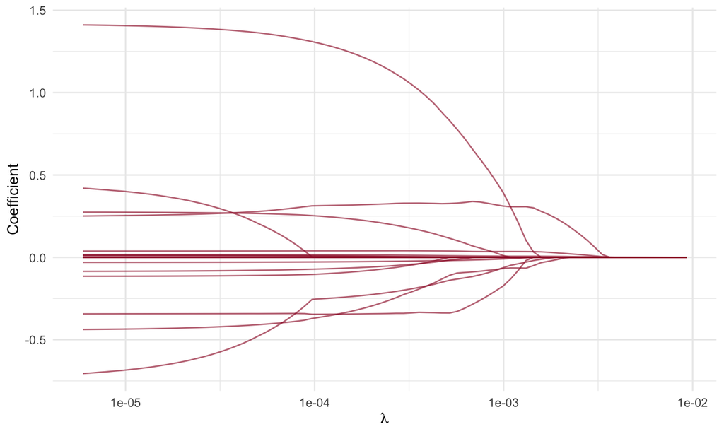

One-lag Lasso coefficient paths from glmnet; each line represents one macroeconomic regressor.

```r
ggplot(glmnet_path_data(lasso1,"Lasso"),aes(lambda,coefficient,group=term)) +
  geom_line(colour="#9e1b32",alpha=.65) + scale_x_log10() +
  labs(x=expression(lambda),y="Coefficient")
```

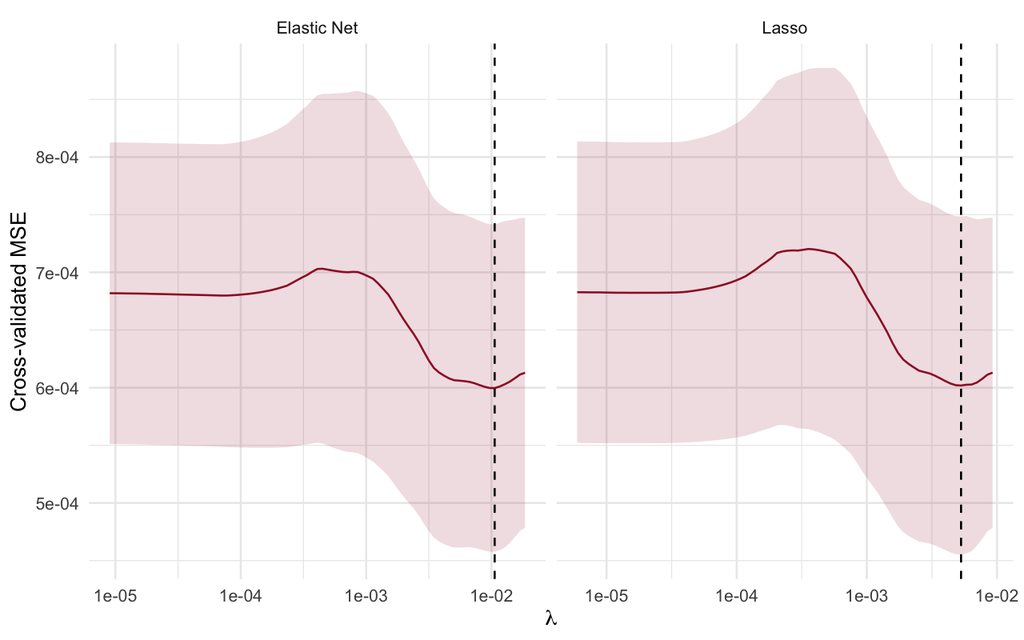

Ten-fold CV for one-lag Lasso and Elastic Net. Ribbons show the CV mean plus or minus the standard error returned by glmnet; dashed lines mark lambda.min.

```r
one_cv <- rbind(glmnet_cv_data(cv_lasso1,"Lasso"),
                 glmnet_cv_data(cv_enet1,"Elastic Net"))
one_cv_choices <- data.frame(method=c("Lasso","Elastic Net"),
                              lambda=c(cv_lasso1$lambda.min,cv_enet1$lambda.min))
ggplot(one_cv,aes(lambda,mse)) +
  geom_ribbon(aes(ymin=mse-se,ymax=mse+se),fill="#9e1b32",alpha=.15) +
  geom_line(colour="#9e1b32") +
  geom_vline(data=one_cv_choices,aes(xintercept=lambda),linetype=2) +
  facet_wrap(~method,scales="free_x") + scale_x_log10() +
  labs(x=expression(lambda),y="Cross-validated MSE")
```

`lambda.min` minimizes the CV error. `lambda.1se` is the largest candidate within one standard error of that minimum. We name the choice explicitly rather than relying on the default of `coef()`.

```r
one_selected <- rbind(
  selected_coefficients(cv_lasso1,"lambda.min","Lasso"),
  selected_coefficients(cv_lasso1,"lambda.1se","Lasso"),
  selected_coefficients(cv_enet1,"lambda.min","Elastic Net"),
  selected_coefficients(cv_enet1,"lambda.1se","Elastic Net"))
knitr::kable(one_selected,digits=5)
```

| method | rule | term | coefficient |
| --- | --- | --- | --- |
| Lasso | lambda.min | (Intercept) | 0.02455 |
| Lasso | lambda.min | PPIACO_l1 | 0.00079 |
| Lasso | lambda.1se | (Intercept) | 0.02544 |
| Elastic Net | lambda.min | (Intercept) | 0.02471 |
| Elastic Net | lambda.min | PPIACO_l1 | 0.00065 |
| Elastic Net | lambda.1se | (Intercept) | 0.02544 |

```r
stopifnot(max(abs(as.matrix(coef(enet1_selected))-
                 as.matrix(coef(cv_enet1,s="lambda.min"))))<1e-3)
```

## 4.4 Exhaustive best-subset selection

The original best-subset analysis searches models of size one through eight, using the 18 first-lag predictors. This is an exhaustive search **within that size range**, not a search restricted to the first eight variables. The intercept is included in every model.

```r
subset_fit <- leaps::regsubsets(x=X1_scaled,y=y_original_scaled,
                                method="exhaustive",nvmax=8)
subset_summary <- summary(subset_fit)
subset_summary
```

```
## Subset selection object
## 18 Variables  (and intercept)
##             Forced in Forced out
## UNRATE_l1       FALSE      FALSE
## EC_l1           FALSE      FALSE
## PRFI_l1         FALSE      FALSE
## GDPC1_l1        FALSE      FALSE
## HOUST_l1        FALSE      FALSE
## USPRIV_l1       FALSE      FALSE
## TB3MS_l1        FALSE      FALSE
## GS10_l1         FALSE      FALSE
## T10Y3MM_l1      FALSE      FALSE
## T10YFFM_l1      FALSE      FALSE
## M1SL_l1         FALSE      FALSE
## MICH_l1         FALSE      FALSE
## PPIACO_l1       FALSE      FALSE
## DJIA_l1         FALSE      FALSE
## NAPMPMI_l1      FALSE      FALSE
## NAPMSDI_l1      FALSE      FALSE
## OILPRICE_l1     FALSE      FALSE
## GASPRICE_l1     FALSE      FALSE
## 1 subsets of each size up to 8
## Selection Algorithm: exhaustive
##          UNRATE_l1 EC_l1 PRFI_l1 GDPC1_l1 HOUST_l1 USPRIV_l1 TB3MS_l1 GS10_l1
## 1  ( 1 ) " "       " "   " "     " "      " "      " "       " "      " "
## 2  ( 1 ) " "       " "   " "     " "      " "      " "       " "      " "
## 3  ( 1 ) " "       "*"   " "     "*"      " "      " "       " "      " "
## 4  ( 1 ) " "       "*"   " "     "*"      " "      " "       " "      " "
## 5  ( 1 ) " "       "*"   " "     "*"      " "      " "       " "      " "
## 6  ( 1 ) " "       "*"   " "     "*"      "*"      " "       " "      " "
## 7  ( 1 ) " "       "*"   "*"     "*"      "*"      " "       " "      " "
## 8  ( 1 ) " "       "*"   "*"     "*"      "*"      " "       " "      " "
##          T10Y3MM_l1 T10YFFM_l1 M1SL_l1 MICH_l1 PPIACO_l1 DJIA_l1 NAPMPMI_l1
## 1  ( 1 ) " "        " "        " "     " "     "*"       " "     " "
## 2  ( 1 ) " "        " "        " "     " "     "*"       " "     " "
## 3  ( 1 ) " "        " "        " "     " "     "*"       " "     " "
## 4  ( 1 ) " "        " "        " "     " "     "*"       " "     " "
## 5  ( 1 ) "*"        " "        " "     " "     "*"       " "     " "
## 6  ( 1 ) "*"        " "        " "     " "     "*"       " "     " "
## 7  ( 1 ) " "        " "        " "     " "     "*"       "*"     " "
## 8  ( 1 ) " "        " "        " "     " "     "*"       "*"     "*"
##          NAPMSDI_l1 OILPRICE_l1 GASPRICE_l1
## 1  ( 1 ) " "        " "         " "
## 2  ( 1 ) " "        " "         "*"
## 3  ( 1 ) " "        " "         " "
## 4  ( 1 ) " "        " "         "*"
## 5  ( 1 ) " "        " "         "*"
## 6  ( 1 ) " "        " "         "*"
## 7  ( 1 ) " "        " "         "*"
## 8  ( 1 ) " "        " "         "*"
```

```r
subset_criteria <- data.frame(size=seq_along(subset_summary$bic),
                              BIC=subset_summary$bic,
                              Cp=subset_summary$cp,RSS=subset_summary$rss)
best_subset_size <- which.min(subset_summary$bic)
subset_coefficients <- coef(subset_fit,id=best_subset_size)
subset_terms <- setdiff(names(subset_coefficients),"(Intercept)")
subset_data <- data.frame(response=y_original_scaled,X1_scaled,check.names=FALSE)
subset_refit <- lm(reformulate(subset_terms,response="response"),data=subset_data)
coef(subset_refit)
```

```
##   (Intercept)         EC_l1      GDPC1_l1     PPIACO_l1   GASPRICE_l1
##  3.912813e-16 -6.958761e-01  6.777184e-01  7.424334e-01 -4.390489e-01
```

```r
stopifnot(max(abs(coef(subset_refit)[names(subset_coefficients)]-
                   subset_coefficients))<1e-7)
```

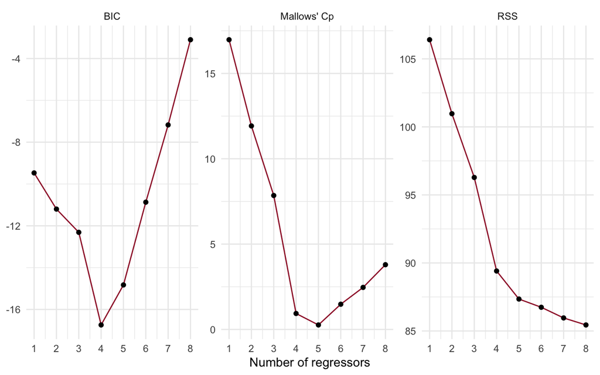

BIC, Mallows’ Cp and residual sum of squares for the best subset at each size. Separate vertical scales avoid comparing unlike criteria numerically.

```r
subset_plot <- data.frame(size=rep(subset_criteria$size,3),
 value=c(subset_criteria$BIC,subset_criteria$Cp,subset_criteria$RSS),
 criterion=rep(c("BIC","Mallows' Cp","RSS"),each=nrow(subset_criteria)))
ggplot(subset_plot,aes(size,value)) + geom_line(colour="#9e1b32") +
 geom_point() + facet_wrap(~criterion,scales="free_y") +
 scale_x_continuous(breaks=1:8) + labs(x="Number of regressors",y=NULL)
```

The selected subset contains **4 regressors**. These coefficients are on standardized scales, unlike the raw-scale OLS table above. The comparison is descriptive: neither the subset search nor its printed OLS standard errors account automatically for selection uncertainty.

## 4.5 Ridge and OLS pilots for adaptive Lasso

We restore both pilot constructions. The original code computed ridge and OLS weights but used only the OLS weights in its adaptive-Lasso fit; here both are fitted and displayed. A small explicit floor prevents division by zero when constructing inverse absolute-value weights.

```r
set.seed(1234)
folds_adaptive <- sample(rep(seq_len(10),length.out=length(y_original)))
cv_ridge1 <- glmnet::cv.glmnet(X1,y_original,alpha=0,standardize=TRUE,
                              foldid=folds_adaptive,type.measure="mse")
cv_ridge1
```

```
##
## Call:  glmnet::cv.glmnet(x = X1, y = y_original, type.measure = "mse",      foldid = folds_adaptive, alpha = 0, standardize = TRUE)
##
## Measure: Mean-Squared Error
##
##     Lambda Index   Measure        SE Nonzero
## min  0.170    44 0.0006057 0.0001089      18
## 1se  9.259     1 0.0006167 0.0001174      18
```

```r
ridge_pilot <- as.matrix(coef(cv_ridge1,s="lambda.min"))[-1,1]
ols_pilot <- coef(ols1)[colnames(X1)]
weight_floor <- 1e-8
ridge_weights <- 1/pmax(abs(ridge_pilot),weight_floor)
ols_weights <- 1/pmax(abs(ols_pilot),weight_floor)
pilot_table <- data.frame(term=colnames(X1),ridge=ridge_pilot,OLS=ols_pilot,
                          ridge_weight=ridge_weights,OLS_weight=ols_weights)
knitr::kable(pilot_table,digits=5,row.names=FALSE)
```

| term | ridge | OLS | ridge_weight | OLS_weight |
| --- | --- | --- | --- | --- |
| UNRATE_l1 | -0.00464 | 0.27502 | 215.38004 | 3.63611 |
| EC_l1 | -0.00213 | -0.34187 | 470.08553 | 2.92513 |
| PRFI_l1 | 0.00335 | -0.08574 | 298.56300 | 11.66321 |
| GDPC1_l1 | 0.03447 | 1.41711 | 29.00936 | 0.70566 |
| HOUST_l1 | 0.00152 | 0.01677 | 659.85959 | 59.64177 |
| USPRIV_l1 | -0.00594 | -0.44353 | 168.33408 | 2.25465 |
| TB3MS_l1 | 0.00391 | -0.11522 | 255.65726 | 8.67931 |
| GS10_l1 | 0.00032 | -0.00053 | 3125.98328 | 1896.94585 |
| T10Y3MM_l1 | -0.02310 | -0.75627 | 43.28138 | 1.32228 |
| T10YFFM_l1 | -0.01681 | 0.46749 | 59.48810 | 2.13909 |
| M1SL_l1 | -0.00020 | 0.01235 | 4930.11479 | 80.97719 |
| MICH_l1 | 0.09890 | 0.24519 | 10.11097 | 4.07848 |
| PPIACO_l1 | 0.00020 | 0.00295 | 4981.31878 | 338.41853 |
| DJIA_l1 | 0.00862 | 0.03736 | 116.04012 | 26.76343 |
| NAPMPMI_l1 | 0.00003 | -0.00031 | 33884.13136 | 3200.50282 |
| NAPMSDI_l1 | 0.00003 | -0.00022 | 30596.32843 | 4547.79910 |
| OILPRICE_l1 | 0.00198 | 0.01261 | 505.45799 | 79.29836 |
| GASPRICE_l1 | 0.00133 | -0.03029 | 751.93915 | 33.01928 |

```r
cv_adaptive_ols <- glmnet::cv.glmnet(X1,y_original,alpha=1,
  standardize=TRUE,foldid=folds_adaptive,type.measure="mse",penalty.factor=ols_weights)
cv_adaptive_ridge <- glmnet::cv.glmnet(X1,y_original,alpha=1,
  standardize=TRUE,foldid=folds_adaptive,type.measure="mse",penalty.factor=ridge_weights)
```

These CV curves retain the original **fixed full-sample pilot** workflow: the pilots are not recomputed inside validation folds. Consequently they compare penalties conditional on those estimated weights, rather than providing leakage-free validation of the complete adaptive procedure. `glmnet` also rescales `penalty.factor` internally, so raw tuning values should not be equated with tuning values from a different solver without aligning its normalization.

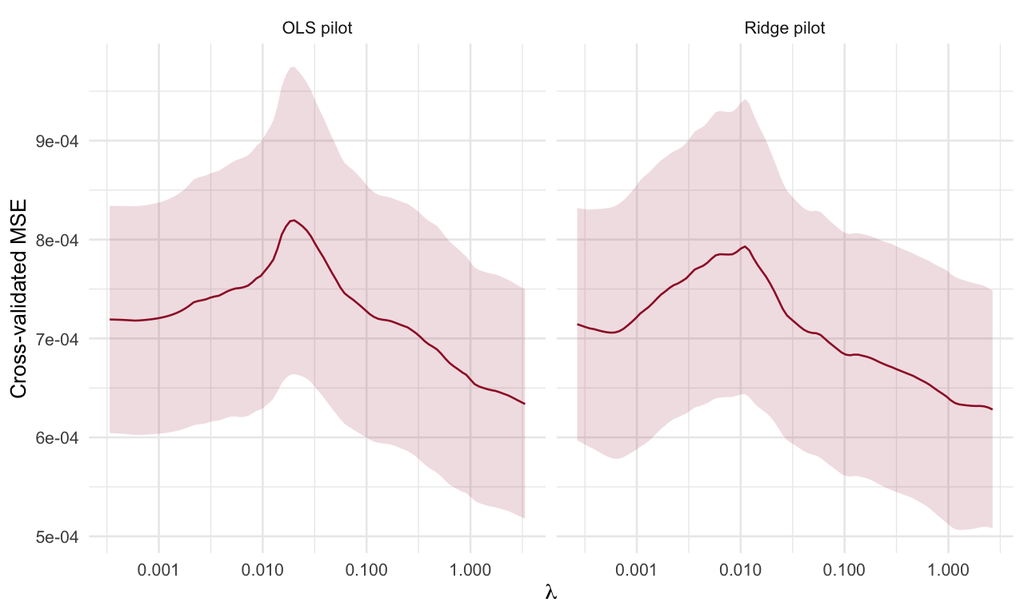

CV curves for adaptive Lasso using OLS and ridge pilots, with full-sample weights held fixed throughout CV.

```r
adaptive_cv_plot <- rbind(glmnet_cv_data(cv_adaptive_ols,"OLS pilot"),
                          glmnet_cv_data(cv_adaptive_ridge,"Ridge pilot"))
ggplot(adaptive_cv_plot,aes(lambda,mse)) +
 geom_ribbon(aes(ymin=mse-se,ymax=mse+se),fill="#9e1b32",alpha=.15) +
 geom_line(colour="#9e1b32") + facet_wrap(~method,scales="free_x") +
 scale_x_log10() + labs(x=expression(lambda),y="Cross-validated MSE")
```

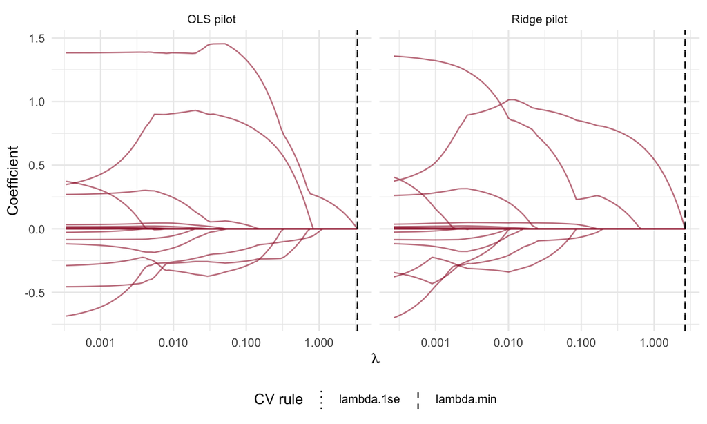

Adaptive coefficient paths for the two pilots. Dashed and dotted lines mark lambda.min and lambda.1se, respectively.

```r
adaptive_paths <- rbind(glmnet_path_data(cv_adaptive_ols$glmnet.fit,"OLS pilot"),
                         glmnet_path_data(cv_adaptive_ridge$glmnet.fit,"Ridge pilot"))
adaptive_choices <- data.frame(method=rep(c("OLS pilot","Ridge pilot"),each=2),
 rule=rep(c("lambda.min","lambda.1se"),2),
 lambda=c(cv_adaptive_ols$lambda.min,cv_adaptive_ols$lambda.1se,
          cv_adaptive_ridge$lambda.min,cv_adaptive_ridge$lambda.1se))
ggplot(adaptive_paths,aes(lambda,coefficient,group=term)) +
 geom_line(colour="#9e1b32",alpha=.6) +
 geom_vline(data=adaptive_choices,aes(xintercept=lambda,linetype=rule),inherit.aes=FALSE) +
 scale_linetype_manual(values=c("lambda.min"="dashed","lambda.1se"="dotted")) +
 facet_wrap(~method,scales="free_x") + scale_x_log10() +
 labs(x=expression(lambda),y="Coefficient",linetype="CV rule")
```

```r
adaptive_selected <- rbind(
 selected_coefficients(cv_adaptive_ols,"lambda.1se","OLS pilot"),
 selected_coefficients(cv_adaptive_ridge,"lambda.1se","Ridge pilot"))
knitr::kable(adaptive_selected,digits=5)
```

| method | rule | term | coefficient |
| --- | --- | --- | --- |
| OLS pilot | lambda.1se | (Intercept) | 0.02544 |
| Ridge pilot | lambda.1se | (Intercept) | 0.02544 |

## 4.6 Bayesian model averaging: simulation and full enumeration

We restore both BMS analyses: reversible-jump model sampling and enumeration of all $2^{18}=262{,}144$ subsets. Both use a uniform prior over models and the same unit-information prior (`g="UIP"`). The sampled run uses 10,000 burn-in iterations followed by 50,000 iterations, matching the original settings (Zeugner and Feldkircher 2015).

```r
BMS_data <- data.frame(response=y_original,X1,check.names=FALSE)
set.seed(417)
bma_sample <- BMS::bms(BMS_data,burn=10000,iter=50000,
  mprior="uniform",g="UIP",mcmc="rev.jump",nmodel=100,
  user.int=FALSE,logfile=FALSE)
bma_enumeration <- BMS::bms(BMS_data,mprior="uniform",g="UIP",
  mcmc="enumerate",nmodel=100,user.int=FALSE,logfile=FALSE)
summary(bma_sample)
```

```
## Mean no. regressors               Draws             Burnins                Time
##            "5.3674"             "50000"             "10000"     "1.095494 secs"
##  No. models visited      Modelspace 2^K           % visited         % Topmodels
##             "13799"            "262144"               "5.3"                "60"
##            Corr PMP            No. Obs.         Model Prior             g-Prior
##            "0.9947"               "125"       "uniform / 9"               "UIP"
##     Shrinkage-Stats
##         "Av=0.9921"
```

```r
summary(bma_enumeration)
```

```
## Mean no. regressors               Draws             Burnins                Time
##            "5.3906"            "262144"                 "0"     "4.960132 secs"
##  No. models visited      Modelspace 2^K           % visited         % Topmodels
##            "262144"            "262144"               "100"             "0.038"
##            Corr PMP            No. Obs.         Model Prior             g-Prior
##                "NA"               "125"       "uniform / 9"               "UIP"
##     Shrinkage-Stats
##         "Av=0.9921"
```

The original comment referred to the 100 best models, while the code retained only ten. We now retain 100 explicitly. Three quantities must be distinguished: MCMC-frequency summaries, full-enumeration summaries, and summaries restricted to the retained best models. In BMS, `exact=TRUE` uses the marginal-likelihood weights of those retained models; it does not automatically mean averaging over the entire model space.

```r
bma_sample_coef <- coef(bma_sample,exact=FALSE,order.by.pip=FALSE,
                         include.constant=FALSE,std.coefs=FALSE)
bma_full_coef <- coef(bma_enumeration,exact=FALSE,order.by.pip=FALSE,
                       include.constant=FALSE,std.coefs=FALSE)
bma_top100_coef <- coef(bma_sample,exact=TRUE,order.by.pip=FALSE,
                         include.constant=TRUE,std.coefs=FALSE)
knitr::kable(bma_top100_coef,digits=5,
 caption="Posterior coefficient summaries restricted to the 100 best retained models, including the intercept.")
```

Posterior coefficient summaries restricted to the 100 best retained models, including the intercept.

|  | PIP | Post Mean | Post SD | Cond.Pos.Sign | Idx |
| --- | --- | --- | --- | --- | --- |
| UNRATE_l1 | 0.05179 | -0.00322 | 0.03094 | 0.19814 | 1 |
| EC_l1 | 0.90379 | -0.68434 | 0.29728 | 0.00000 | 2 |
| PRFI_l1 | 0.04443 | -0.00153 | 0.01413 | 0.00000 | 3 |
| GDPC1_l1 | 0.96643 | 1.34077 | 0.45575 | 1.00000 | 4 |
| HOUST_l1 | 0.13673 | 0.00109 | 0.00349 | 1.00000 | 5 |
| USPRIV_l1 | 0.12428 | -0.04722 | 0.16812 | 0.00000 | 6 |
| TB3MS_l1 | 0.05749 | 0.00411 | 0.02994 | 1.00000 | 7 |
| GS10_l1 | 0.03052 | 0.00000 | 0.00081 | 0.33776 | 8 |
| T10Y3MM_l1 | 0.17266 | -0.05061 | 0.16110 | 0.00000 | 9 |
| T10YFFM_l1 | 0.12616 | -0.01865 | 0.12729 | 0.07040 | 10 |
| M1SL_l1 | 0.08661 | 0.00142 | 0.00637 | 0.93213 | 11 |
| MICH_l1 | 0.05908 | 0.01486 | 0.09867 | 1.00000 | 12 |
| PPIACO_l1 | 1.00000 | 0.00345 | 0.00085 | 1.00000 | 13 |
| DJIA_l1 | 0.08502 | 0.00302 | 0.01404 | 1.00000 | 14 |
| NAPMPMI_l1 | 0.05950 | -0.00003 | 0.00021 | 0.00000 | 15 |
| NAPMSDI_l1 | 0.04617 | -0.00001 | 0.00012 | 0.00000 | 16 |
| OILPRICE_l1 | 0.05475 | 0.00062 | 0.00506 | 0.95420 | 17 |
| GASPRICE_l1 | 0.92546 | -0.03106 | 0.01401 | 0.00000 | 18 |
| (Intercept) | 1.00000 | 0.01142 | NA | NA | 0 |

```r
bma_comparison <- data.frame(term=rownames(bma_full_coef),
 PIP_sample=bma_sample_coef[,"PIP"],PIP_enumeration=bma_full_coef[,"PIP"],
 mean_sample=bma_sample_coef[,"Post Mean"],mean_enumeration=bma_full_coef[,"Post Mean"])
knitr::kable(bma_comparison,digits=5,row.names=FALSE)
```

| term | PIP_sample | PIP_enumeration | mean_sample | mean_enumeration |
| --- | --- | --- | --- | --- |
| UNRATE_l1 | 0.09848 | 0.10047 | -0.00101 | -0.00025 |
| EC_l1 | 0.81932 | 0.80218 | -0.60495 | -0.58967 |
| PRFI_l1 | 0.09520 | 0.09625 | -0.00301 | -0.00295 |
| GDPC1_l1 | 0.90182 | 0.89632 | 1.22489 | 1.21241 |
| HOUST_l1 | 0.18288 | 0.18305 | 0.00150 | 0.00152 |
| USPRIV_l1 | 0.19478 | 0.20818 | -0.06624 | -0.07604 |
| TB3MS_l1 | 0.10176 | 0.09990 | 0.00500 | 0.00490 |
| GS10_l1 | 0.08040 | 0.08465 | -0.00004 | -0.00004 |
| T10Y3MM_l1 | 0.20180 | 0.20501 | -0.06692 | -0.07006 |
| T10YFFM_l1 | 0.14888 | 0.15567 | -0.00891 | -0.00756 |
| M1SL_l1 | 0.13514 | 0.15394 | 0.00171 | 0.00207 |
| MICH_l1 | 0.11478 | 0.11874 | 0.03428 | 0.03551 |
| PPIACO_l1 | 0.99646 | 0.99645 | 0.00327 | 0.00327 |
| DJIA_l1 | 0.13996 | 0.14490 | 0.00547 | 0.00567 |
| NAPMPMI_l1 | 0.11308 | 0.10487 | -0.00005 | -0.00005 |
| NAPMSDI_l1 | 0.10152 | 0.09429 | -0.00002 | -0.00002 |
| OILPRICE_l1 | 0.09818 | 0.10265 | 0.00075 | 0.00080 |
| GASPRICE_l1 | 0.84300 | 0.84312 | -0.02805 | -0.02800 |

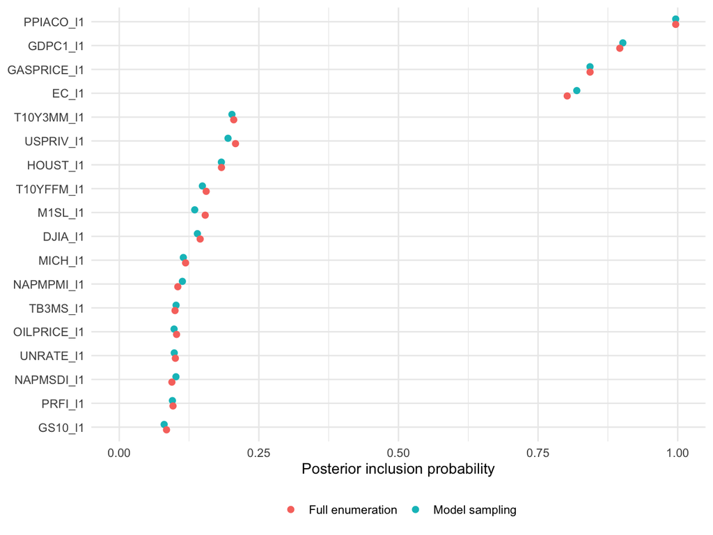

Posterior inclusion probabilities from the sampled run and full enumeration of the one-lag model space. A single sampled run is a comparison, not a convergence guarantee.

```r
pip_plot <- data.frame(term=rep(bma_comparison$term,2),
 PIP=c(bma_comparison$PIP_sample,bma_comparison$PIP_enumeration),
 method=rep(c("Model sampling","Full enumeration"),each=nrow(bma_comparison)))
ggplot(pip_plot,aes(PIP,reorder(term,PIP),colour=method)) +
 geom_point(position=position_dodge(width=.45),size=2) +
 scale_x_continuous(limits=c(0,1)) + labs(x="Posterior inclusion probability",y=NULL,colour=NULL)
```

The next tables recover the original inspection of the best models using the public `topmodels.bma()` accessor. The indicator rows show which regressors enter each model. The last row reports relative posterior weights normalized over the 100 retained models, of which eight are displayed. These conditional weights must not be interpreted as posterior probabilities over all 262,144 models. Full-model-space inclusion probabilities are reported above.

```r
retained_model_table <- function(fit, n=8L) {
  tab <- BMS::topmodels.bma(fit)
  weights <- tab["PMP (Exact)", ]
  stopifnot(all(is.finite(weights)), all(weights >= 0), sum(weights) > 0)
  weights <- weights / sum(weights)
  out <- rbind(tab[fit$reg.names, , drop=FALSE],
               "Posterior weight conditional on retained models"=weights)
  out[, seq_len(min(n,ncol(out))), drop=FALSE]
}
top_sample <- retained_model_table(bma_sample)
top_enumeration <- retained_model_table(bma_enumeration)
knitr::kable(top_sample,digits=4,caption="Eight best retained models from the sampled run; weights are conditional on the 100 retained models.")
```

Eight best retained models from the sampled run; weights are conditional on the 100 retained models.

|  | 14021 | 14221 | 16021 | 14121 | 14031 | 14821 | 34021 | 14029 |
| --- | --- | --- | --- | --- | --- | --- | --- | --- |
| UNRATE_l1 | 0.0000 | 0.000 | 0.0000 | 0.0000 | 0.000 | 0.0000 | 1.0000 | 0.0000 |
| EC_l1 | 1.0000 | 1.000 | 1.0000 | 1.0000 | 1.000 | 1.0000 | 1.0000 | 1.0000 |
| PRFI_l1 | 0.0000 | 0.000 | 0.0000 | 0.0000 | 0.000 | 0.0000 | 0.0000 | 0.0000 |
| GDPC1_l1 | 1.0000 | 1.000 | 1.0000 | 1.0000 | 1.000 | 1.0000 | 1.0000 | 1.0000 |
| HOUST_l1 | 0.0000 | 0.000 | 1.0000 | 0.0000 | 0.000 | 0.0000 | 0.0000 | 0.0000 |
| USPRIV_l1 | 0.0000 | 0.000 | 0.0000 | 0.0000 | 0.000 | 0.0000 | 0.0000 | 0.0000 |
| TB3MS_l1 | 0.0000 | 0.000 | 0.0000 | 0.0000 | 0.000 | 1.0000 | 0.0000 | 0.0000 |
| GS10_l1 | 0.0000 | 0.000 | 0.0000 | 0.0000 | 0.000 | 0.0000 | 0.0000 | 0.0000 |
| T10Y3MM_l1 | 0.0000 | 1.000 | 0.0000 | 0.0000 | 0.000 | 0.0000 | 0.0000 | 0.0000 |
| T10YFFM_l1 | 0.0000 | 0.000 | 0.0000 | 1.0000 | 0.000 | 0.0000 | 0.0000 | 0.0000 |
| M1SL_l1 | 0.0000 | 0.000 | 0.0000 | 0.0000 | 0.000 | 0.0000 | 0.0000 | 0.0000 |
| MICH_l1 | 0.0000 | 0.000 | 0.0000 | 0.0000 | 0.000 | 0.0000 | 0.0000 | 0.0000 |
| PPIACO_l1 | 1.0000 | 1.000 | 1.0000 | 1.0000 | 1.000 | 1.0000 | 1.0000 | 1.0000 |
| DJIA_l1 | 0.0000 | 0.000 | 0.0000 | 0.0000 | 1.000 | 0.0000 | 0.0000 | 0.0000 |
| NAPMPMI_l1 | 0.0000 | 0.000 | 0.0000 | 0.0000 | 0.000 | 0.0000 | 0.0000 | 1.0000 |
| NAPMSDI_l1 | 0.0000 | 0.000 | 0.0000 | 0.0000 | 0.000 | 0.0000 | 0.0000 | 0.0000 |
| OILPRICE_l1 | 0.0000 | 0.000 | 0.0000 | 0.0000 | 0.000 | 0.0000 | 0.0000 | 0.0000 |
| GASPRICE_l1 | 1.0000 | 1.000 | 1.0000 | 1.0000 | 1.000 | 1.0000 | 1.0000 | 1.0000 |
| Posterior weight conditional on retained models | 0.1774 | 0.066 | 0.0482 | 0.0467 | 0.027 | 0.0254 | 0.0232 | 0.0228 |

```r
knitr::kable(top_enumeration,digits=4,caption="Eight best models from enumeration; weights are conditional on the 100 retained models.")
```

Eight best models from enumeration; weights are conditional on the 100 retained models.

|  | 14021 | 14221 | 16021 | 14121 | 14031 | 14821 | 34021 | 14029 |
| --- | --- | --- | --- | --- | --- | --- | --- | --- |
| UNRATE_l1 | 0.0000 | 0.000 | 0.0000 | 0.0000 | 0.000 | 0.0000 | 1.0000 | 0.0000 |
| EC_l1 | 1.0000 | 1.000 | 1.0000 | 1.0000 | 1.000 | 1.0000 | 1.0000 | 1.0000 |
| PRFI_l1 | 0.0000 | 0.000 | 0.0000 | 0.0000 | 0.000 | 0.0000 | 0.0000 | 0.0000 |
| GDPC1_l1 | 1.0000 | 1.000 | 1.0000 | 1.0000 | 1.000 | 1.0000 | 1.0000 | 1.0000 |
| HOUST_l1 | 0.0000 | 0.000 | 1.0000 | 0.0000 | 0.000 | 0.0000 | 0.0000 | 0.0000 |
| USPRIV_l1 | 0.0000 | 0.000 | 0.0000 | 0.0000 | 0.000 | 0.0000 | 0.0000 | 0.0000 |
| TB3MS_l1 | 0.0000 | 0.000 | 0.0000 | 0.0000 | 0.000 | 1.0000 | 0.0000 | 0.0000 |
| GS10_l1 | 0.0000 | 0.000 | 0.0000 | 0.0000 | 0.000 | 0.0000 | 0.0000 | 0.0000 |
| T10Y3MM_l1 | 0.0000 | 1.000 | 0.0000 | 0.0000 | 0.000 | 0.0000 | 0.0000 | 0.0000 |
| T10YFFM_l1 | 0.0000 | 0.000 | 0.0000 | 1.0000 | 0.000 | 0.0000 | 0.0000 | 0.0000 |
| M1SL_l1 | 0.0000 | 0.000 | 0.0000 | 0.0000 | 0.000 | 0.0000 | 0.0000 | 0.0000 |
| MICH_l1 | 0.0000 | 0.000 | 0.0000 | 0.0000 | 0.000 | 0.0000 | 0.0000 | 0.0000 |
| PPIACO_l1 | 1.0000 | 1.000 | 1.0000 | 1.0000 | 1.000 | 1.0000 | 1.0000 | 1.0000 |
| DJIA_l1 | 0.0000 | 0.000 | 0.0000 | 0.0000 | 1.000 | 0.0000 | 0.0000 | 0.0000 |
| NAPMPMI_l1 | 0.0000 | 0.000 | 0.0000 | 0.0000 | 0.000 | 0.0000 | 0.0000 | 1.0000 |
| NAPMSDI_l1 | 0.0000 | 0.000 | 0.0000 | 0.0000 | 0.000 | 0.0000 | 0.0000 | 0.0000 |
| OILPRICE_l1 | 0.0000 | 0.000 | 0.0000 | 0.0000 | 0.000 | 0.0000 | 0.0000 | 0.0000 |
| GASPRICE_l1 | 1.0000 | 1.000 | 1.0000 | 1.0000 | 1.000 | 1.0000 | 1.0000 | 1.0000 |
| Posterior weight conditional on retained models | 0.1774 | 0.066 | 0.0482 | 0.0467 | 0.027 | 0.0254 | 0.0232 | 0.0228 |

## 4.7 Extend the regression to four lags

The four-lag OLS model includes all 72 macroeconomic predictor columns. These are lags of the macroeconomic indicators; no lagged inflation regressor is added by this code. The larger model has fewer residual degrees of freedom, which makes its in-sample fit a poor substitute for a prediction assessment.

```r
formula4 <- reformulate(all_lag_names,response="CPIAUCSL")
ols4 <- lm(formula4,data=inflation)
summary(ols4)
```

```
##
## Call:
## lm(formula = formula4, data = inflation)
##
## Residuals:
##       Min        1Q    Median        3Q       Max
## -0.037671 -0.008337  0.000313  0.007581  0.034534
##
## Coefficients:
##               Estimate Std. Error t value Pr(>|t|)
## (Intercept) -2.990e-02  1.103e-01  -0.271 0.787445
## UNRATE_l1    2.235e+00  1.399e+00   1.598 0.116176
## EC_l1       -9.678e-01  7.169e-01  -1.350 0.182876
## PRFI_l1     -3.207e-02  1.376e-01  -0.233 0.816658
## GDPC1_l1     1.619e+00  5.422e-01   2.985 0.004314 **
## HOUST_l1    -3.572e-02  4.074e-02  -0.877 0.384667
## USPRIV_l1    1.733e+00  1.319e+00   1.314 0.194529
## TB3MS_l1     5.613e+01  3.490e+01   1.609 0.113767
## GS10_l1     -5.456e-01  3.361e-01  -1.623 0.110582
## T10Y3MM_l1   5.336e+01  3.405e+01   1.567 0.123114
## T10YFFM_l1   1.343e+00  2.523e+00   0.532 0.596653
## M1SL_l1      6.834e-02  1.031e-01   0.663 0.510388
## MICH_l1     -7.531e-01  8.151e-01  -0.924 0.359771
## PPIACO_l1    4.894e-03  1.294e-03   3.781 0.000404 ***
## DJIA_l1      2.863e-03  5.818e-02   0.049 0.960936
## NAPMPMI_l1  -1.881e-03  1.427e-03  -1.318 0.193226
## NAPMSDI_l1   4.556e-04  1.128e-03   0.404 0.687902
## OILPRICE_l1  5.085e-02  2.305e-02   2.206 0.031823 *
## GASPRICE_l1 -6.678e-02  1.874e-02  -3.564 0.000792 ***
## UNRATE_l2   -2.293e+00  1.647e+00  -1.393 0.169655
## EC_l2        5.375e-01  8.446e-01   0.636 0.527308
## PRFI_l2     -2.928e-02  1.352e-01  -0.217 0.829407
## GDPC1_l2    -8.193e-01  8.217e-01  -0.997 0.323354
## HOUST_l2     1.964e-03  4.514e-02   0.044 0.965461
## USPRIV_l2    2.456e+00  1.438e+00   1.708 0.093516 .
## TB3MS_l2    -4.215e+01  4.748e+01  -0.888 0.378741
## GS10_l2     -1.257e-01  3.193e-01  -0.394 0.695470
## T10Y3MM_l2  -3.854e+01  4.625e+01  -0.833 0.408538
## T10YFFM_l2  -4.452e+00  3.075e+00  -1.448 0.153642
## M1SL_l2     -6.424e-02  8.639e-02  -0.744 0.460502
```

[output cut: 34 more lines]

```
## T10YFFM_l4  -1.537e-02  1.933e+00  -0.008 0.993685
## M1SL_l4      4.621e-02  2.851e-02   1.621 0.111081
## MICH_l4      9.441e-01  9.988e-01   0.945 0.348906
## PPIACO_l4    5.351e-04  1.407e-03   0.380 0.705165
## DJIA_l4      7.636e-03  5.785e-02   0.132 0.895494
## NAPMPMI_l4  -7.789e-04  1.526e-03  -0.510 0.611994
## NAPMSDI_l4  -1.425e-03  8.924e-04  -1.597 0.116232
## OILPRICE_l4  2.735e-02  2.371e-02   1.154 0.253955
## GASPRICE_l4 -4.151e-02  1.902e-02  -2.183 0.033581 *
## ---
## Signif. codes:  0 '***' 0.001 '**' 0.01 '*' 0.05 '.' 0.1 ' ' 1
##
## Residual standard error: 0.01863 on 52 degrees of freedom
## Multiple R-squared:  0.7611, Adjusted R-squared:  0.4304
## F-statistic: 2.301 on 72 and 52 DF,  p-value: 0.0009658
```

```r
ols_comparison <- data.frame(model=c("One lag","Four lags"),
 regressors=c(ncol(X1),ncol(X4)),residual_df=c(df.residual(ols1),df.residual(ols4)),
 training_MSE=c(mean(residuals(ols1)^2),mean(residuals(ols4)^2)),
 adjusted_R2=c(summary(ols1)$adj.r.squared,summary(ols4)$adj.r.squared))
knitr::kable(ols_comparison,digits=5)
```

| model | regressors | residual_df | training_MSE | adjusted_R2 |
| --- | --- | --- | --- | --- |
| One lag | 18 | 106 | 0.00040 | 0.22881 |
| Four lags | 72 | 52 | 0.00014 | 0.43038 |

```r
lasso4 <- glmnet::glmnet(X4,y_original,alpha=1,standardize=TRUE,nlambda=100)
cv_enet4 <- glmnet::cv.glmnet(X4,y_original,alpha=.5,standardize=TRUE,
                             nlambda=100,foldid=folds1)
enet4_selected <- glmnet::glmnet(X4,y_original,alpha=.5,standardize=TRUE,
                                 lambda=cv_enet4$lambda.min)
coef(enet4_selected)
```

```
## 73 x 1 sparse Matrix of class "dgCMatrix"
##                      s0
## (Intercept) 0.025047600
## UNRATE_l1   .
## EC_l1       .
## PRFI_l1     .
## GDPC1_l1    .
## HOUST_l1    .
## USPRIV_l1   .
## TB3MS_l1    .
## GS10_l1     .
## T10Y3MM_l1  .
## T10YFFM_l1  .
## M1SL_l1     .
## MICH_l1     .
## PPIACO_l1   0.000351257
## DJIA_l1     .
## NAPMPMI_l1  .
## NAPMSDI_l1  .
## OILPRICE_l1 .
## GASPRICE_l1 .
## UNRATE_l2   .
## EC_l2       .
## PRFI_l2     .
## GDPC1_l2    .
## HOUST_l2    .
## USPRIV_l2   .
## TB3MS_l2    .
## GS10_l2     .
## T10Y3MM_l2  .
## T10YFFM_l2  .
## M1SL_l2     .
## MICH_l2     .
## PPIACO_l2   .
## DJIA_l2     .
## NAPMPMI_l2  .
## NAPMSDI_l2  .
## OILPRICE_l2 .
## GASPRICE_l2 .
## UNRATE_l3   .
```

[output cut: 20 more lines]

```
## GDPC1_l4    .
## HOUST_l4    .
## USPRIV_l4   .
## TB3MS_l4    .
## GS10_l4     .
## T10Y3MM_l4  .
## T10YFFM_l4  .
## M1SL_l4     .
## MICH_l4     .
## PPIACO_l4   .
## DJIA_l4     .
## NAPMPMI_l4  .
## NAPMSDI_l4  .
## OILPRICE_l4 .
## GASPRICE_l4 .
```

```r
knitr::kable(selected_coefficients(cv_enet4,"lambda.1se","Four-lag Elastic Net"),digits=5)
```

| method | rule | term | coefficient |
| --- | --- | --- | --- |
| Four-lag Elastic Net | lambda.1se | (Intercept) | 0.02544 |

The four-lag fit, plot and coefficient extraction all refer to `cv_enet4`; they do not reuse the one-lag CV object. The Lasso path is shown separately because it has $\alpha=1$, while the selected Elastic Net has $\alpha=0.5$.

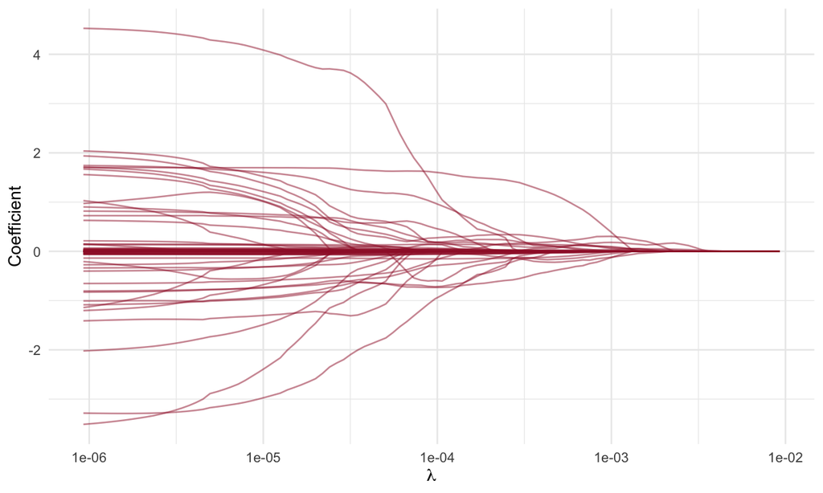

Four-lag Lasso path on the 72-predictor design.

```r
ggplot(glmnet_path_data(lasso4,"Four lags"),aes(lambda,coefficient,group=term)) +
 geom_line(colour="#9e1b32",alpha=.5) + scale_x_log10() +
 labs(x=expression(lambda),y="Coefficient")
```

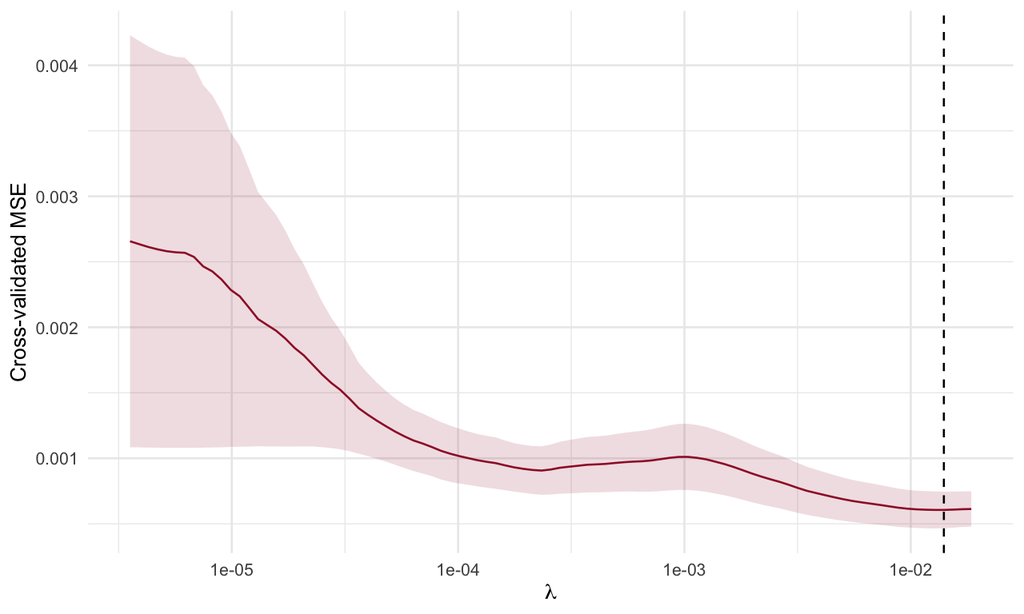

Ten-fold CV for the four-lag Elastic Net. The ribbon is one glmnet standard error; the dashed line marks lambda.min.

```r
ggplot(glmnet_cv_data(cv_enet4,"Four lags"),aes(lambda,mse)) +
 geom_ribbon(aes(ymin=mse-se,ymax=mse+se),fill="#9e1b32",alpha=.15) +
 geom_line(colour="#9e1b32") + geom_vline(xintercept=cv_enet4$lambda.min,linetype=2) +
 scale_x_log10() + labs(x=expression(lambda),y="Cross-validated MSE")
```

## 4.8 The original fdaSP fit and cross-validation

We now reproduce the `fdaSP` portion on the full four-lag design, preserving its automatic standardization and five-fold CV. The exported `fdaSP::lmSP_cv` replaces the unnecessary triple-colon call. We use the CV grid again for the full path so that the selected value can be located without ambiguity.

```r
original_control <- list(adaptation=TRUE,rho=1,maxit=3000,
                          reltol=1e-4,abstol=1e-4,mu.ada=10,tau.ada=2,print.out=FALSE)
set.seed(418)
original_fdasp_cv <- fdaSP::lmSP_cv(X=X4,y=y_original,penalty="LASSO",
  standardize.data=TRUE,intercept=FALSE,cv.fold=5,nlambda=30,
  control=original_control)
original_fdasp_path <- fdaSP::lmSP(X=X4,y=y_original,penalty="LASSO",
  standardize.data=TRUE,intercept=FALSE,lambda=original_fdasp_cv$lambda,
  control=original_control)
stopifnot(all(original_fdasp_path$convergence==1),
          all(original_fdasp_cv$convergence==1),
          all(is.finite(original_fdasp_path$sp.coef.path)))
```

The `mse.sd` component is the standard deviation of fold MSEs in this implementation, not the standard error returned by `glmnet`. We retain the original mean-plus/minus-`mse.sd` band but label it accordingly. It is not a confidence band for the prediction function. The different preprocessing, folds and loss conventions also prevent a direct ranking based solely on the numerical CV values printed by the two packages.

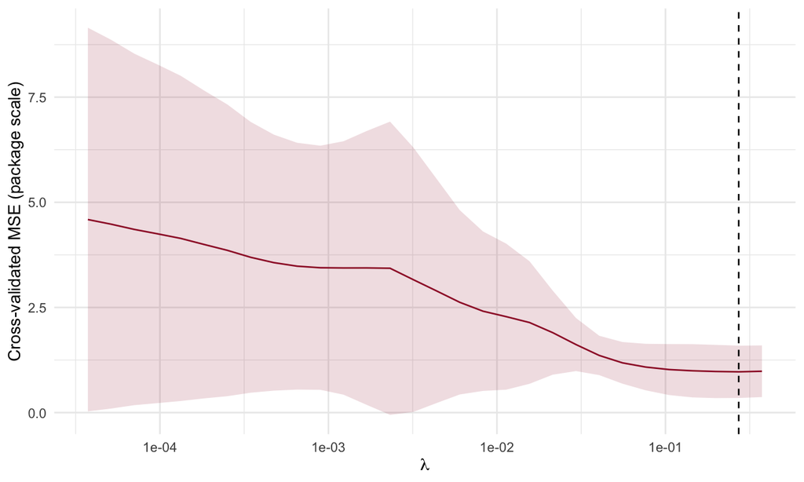

Original fdaSP workflow: five-fold CV error plus or minus one fold-error standard deviation, with the selected lambda marked.

```r
fdasp_cv_plot <- data.frame(lambda=original_fdasp_cv$lambda,
 mse=as.numeric(original_fdasp_cv$mse),sd=as.numeric(original_fdasp_cv$mse.sd))
ggplot(fdasp_cv_plot,aes(lambda,mse)) +
 geom_ribbon(aes(ymin=mse-sd,ymax=mse+sd),fill="#9e1b32",alpha=.15) +
 geom_line(colour="#9e1b32") + geom_vline(xintercept=original_fdasp_cv$lambda.min,linetype=2) +
 scale_x_log10() + labs(x=expression(lambda),y="Cross-validated MSE (package scale)")
```

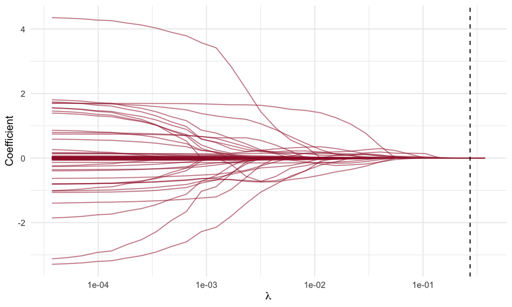

The fdaSP coefficient path from the original four-lag example, evaluated on the same lambda grid as its CV fit.

```r
fdasp_coefficients <- as.matrix(original_fdasp_path$sp.coef.path)
fdasp_original_path_plot <- data.frame(
 lambda=rep(original_fdasp_path$lambda,ncol(fdasp_coefficients)),
 coefficient=as.vector(fdasp_coefficients),
 term=rep(colnames(X4),each=nrow(fdasp_coefficients)))
ggplot(fdasp_original_path_plot,aes(lambda,coefficient,group=term)) +
 geom_line(colour="#9e1b32",alpha=.55) +
 geom_vline(xintercept=original_fdasp_cv$lambda.min,linetype=2) +
 scale_x_log10() + labs(x=expression(lambda),y="Coefficient")
```

## 4.9 What was clarified during restoration

All substantive analyses in the original R Markdown are represented above. The main corrections are consistent use of one- versus four-lag designs, matching $\alpha$ between CV and refitting, explicit `lambda.min` versus `lambda.1se`, and the distinction between the two packages’ uncertainty bands. The supplied data determine the reported date range. Ridge-pilot adaptive Lasso is shown in addition to the original OLS-pilot fit, and the BMS retained model count is aligned with the original comment about 100 models.

The old **“Real estate dataset”** heading had no data, code or results beneath it. No real-estate application is invented here. The original source remains unchanged in `archive/original-README.Rmd`; the chronological analysis in the next chapter is an addition to this restored workflow.

# 5 Inflation: chronological validation

## 5.1 An additional validation example

The preceding chapter restores the original model-comparison workflow. This additional example separates training, validation and test periods chronologically, retaining the same dataset and a Lasso fit with `fdaSP`.

The data are retrieved from the author’s [original repository](https://github.com/maurobernardi/fdaSP). Here `CPIAUCSL` is the response and columns 3–74 are predictors, following the original example. This is a **chronological regression illustration**, not a real-time forecasting experiment: publication lags and data vintages have not been reconstructed.

```r
data_env <- new.env()
load("../data/inflation-Q.RData",envir=data_env)
infl <- data_env$infl.data
y_infl <- as.numeric(infl$CPIAUCSL)
X_infl <- as.matrix(infl[,3:74])
stopifnot(all(is.finite(X_infl)),all(is.finite(y_infl)))
N <- nrow(X_infl)
train <- seq_len(floor(.6*N))
valid <- seq.int(max(train)+1,floor(.8*N))
test <- seq.int(max(valid)+1,N)
data.frame(period=c("Training","Validation","Test"),
           observations=c(length(train),length(valid),length(test)))
```

```
##       period observations
## 1   Training           75
## 2 Validation           25
## 3       Test           25
```

## 5.2 Learn scaling on the training period

Centering and scaling use only training observations. We center the response and add its training mean back to predictions. This avoids relying on a package-specific transformation when applying a fitted model to new rows.

```r
xmean <- colMeans(X_infl[train,,drop=FALSE])
xsd <- apply(X_infl[train,,drop=FALSE],2,sd)
keep <- is.finite(xsd) & xsd>0
X_infl <- X_infl[,keep,drop=FALSE]
xmean <- xmean[keep]; xsd <- xsd[keep]
Xs <- sweep(sweep(X_infl,2,xmean,"-"),2,xsd,"/")
ymean <- mean(y_infl[train])
infl_fit <- lmSP(X=Xs[train,,drop=FALSE],y=y_infl[train]-ymean,
                 penalty="LASSO",nlambda=30,lambda.min.ratio=.001,
                 standardize.data=FALSE,control=control)
check_path(infl_fit)
valid_predictions <- Xs[valid,,drop=FALSE] %*% t(infl_fit$sp.coef.path)+ymean
validation_mse <- colMeans((valid_predictions-y_infl[valid])^2)
i_infl <- which.min(validation_mse)
test_predictions <- drop(Xs[test,,drop=FALSE] %*% infl_fit$sp.coef.path[i_infl,])+ymean
inflation_results <- data.frame(lambda=infl_fit$lambda[i_infl],
 validation_MSE=min(validation_mse),test_MSE=mean((y_infl[test]-test_predictions)^2),
 training_mean_baseline_MSE=mean((y_infl[test]-ymean)^2))
inflation_results
```

```
##       lambda validation_MSE    test_MSE training_mean_baseline_MSE
## 1 0.00965022   0.0004732347 0.001037905                0.001037931
```

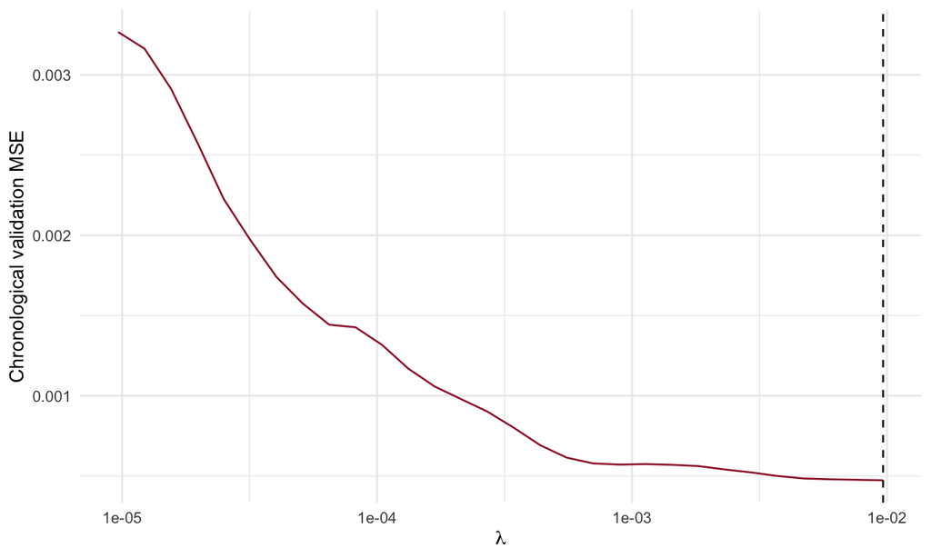

Validation error over the inflation regression path. The test period is not used to choose lambda.

```r
ggplot(data.frame(lambda=infl_fit$lambda,mse=validation_mse),aes(lambda,mse)) +
 geom_line(colour="#9e1b32") + geom_vline(xintercept=infl_fit$lambda[i_infl],linetype=2) +
 scale_x_log10() + labs(x=expression(lambda),y="Chronological validation MSE")
```

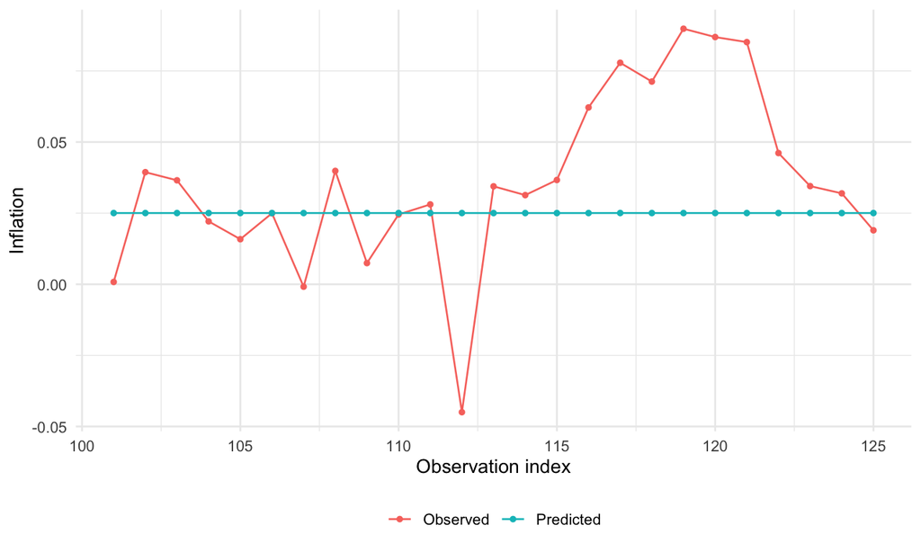

Observed inflation and predictions over the held-out final period; the horizontal axis retains the data’s row order.

```r
infl_plot <- data.frame(observation=rep(test,2),value=c(y_infl[test],test_predictions),
                        series=rep(c("Observed","Predicted"),each=length(test)))
ggplot(infl_plot,aes(observation,value,colour=series)) + geom_line() + geom_point(size=1.2) +
 labs(x="Observation index",y="Inflation",colour=NULL)
```

The result is one held-out comparison, not evidence of universal superiority. For a forecasting study, use predictors available at each forecast origin and rolling or expanding training windows. The original comparisons with other packages are executed and discussed in the preceding chapter.

# 6 Models, penalties and computation

## 6.1 A shared regression structure

After basis expansion, all three model families reduce to penalized regression. For ordinary regression, `X` contains penalized columns and `Z` contains unpenalized columns. For scalar-on-function regression, quadrature-weighted curves produce the design $X_q H$. For function-on-function regression,

$$Y\approx X_q H\Psi\Theta^\top,
\qquad
\operatorname{vec}(Y)\approx
(\Theta\otimes X_qH)\operatorname{vec}(\Psi),$$

where $H$ is $r\times M$, $\Theta$ is $r\times L$, $X_q$ is $n\times r$, and $\Psi$ is $M\times L$. Columnwise vectorization is consistent with R’s matrix storage convention. The Kronecker design has $nr$ rows and $ML$ columns, so increasing both basis sizes can increase computation substantially.

## 6.2 Interpret the penalty

Lasso uses coefficientwise absolute values (Tibshirani 1996). Group Lasso uses Euclidean norms of coefficient blocks (Yuan and Lin 2006). Sparse Group Lasso combines the two (Simon et al. 2013). In overlapping-group models, the same coefficient can enter more than one block; this is how a penalty can encode local support of tensor-product B-splines (Jenatton, Audibert, and Bach 2011; Bernardi, Canale, and Stefanucci 2023).

Adaptive penalties set weights using a pilot fit (Zou 2006). Distinguish group weights, coefficient weights inside group norms, and L1 weights: these generally define different penalties. Also distinguish `adaptive` (statistical weighting) from `control$adaptation` (ADMM step-size adaptation).

Numerical values of `lambda` depend on the loss normalization, predictor scaling, grid weights and group weights. A direct comparison with another solver must first align these conventions. The guide deliberately uses each routine’s own path rather than claiming a universal lambda scale.

## 6.3 ADMM diagnostics

The package exposes the alternating direction method of multipliers (Boyd et al. 2011; Lin, Li, and Fang 2022). A finite iteration budget does not guarantee convergence. Inspect `convergence` along the whole path and, if needed, increase `control$maxit` or inspect the primal and dual residuals. These residuals measure the algorithm’s constraints and stationarity; they are not regression prediction errors.

```r
convergence_table <- data.frame(
 model=c("Lasso","Scalar-on-function","Function-on-function","Inflation"),
 path_points=c(length(fit$lambda),length(scalar_fit$lambda1),
               length(surface_fit$lambda),length(infl_fit$lambda)),
 converged=c(all(fit$convergence==1),all(scalar_fit$convergence==1),
             all(surface_fit$convergence==1),all(infl_fit$convergence==1)))
knitr::kable(convergence_table)
```

| model | path_points | converged |
| --- | --- | --- |
| Lasso | 30 | TRUE |
| Scalar-on-function | 25 | TRUE |
| Function-on-function | 20 | TRUE |
| Inflation | 30 | TRUE |

## 6.4 What the selection criteria measure

Training error measures agreement with observed responses. Cross-validation estimates predictive performance under a specified splitting scheme. BIC balances fit and a complexity estimate. These criteria need not choose the same point on a path. Likewise, a fixed-tuning degrees-of-freedom calculation does not automatically include the complexity of choosing the tuning parameter using the same data.

For functional data, split entire independent subjects rather than time points within subjects. For temporally ordered data, preserve time order. For adaptive penalties, recompute pilots and weights using training data only.

## 6.5 Reproducibility

All figures and printed numerical results in the guide are generated by its R chunks. Seeds, tuning grids and tolerances appear beside the calls. The build also saves summary tables and the R session information in `results/`.

```r
packageVersion("fdaSP")
```

```
## [1] '1.1.3'
```

# References

Bernardi, Mauro, Antonio Canale, and Marco Stefanucci. 2023. “Locally Sparse Function-on-Function Regression.” *Journal of Computational and Graphical Statistics* 32 (3): 985–99. https://doi.org/10.1080/10618600.2022.2130926.

Bernardi, Mauro, Roberto Casarin, Bertrand Maillet, and Lea Petrella. 2024. “Bayesian Dynamic Quantile Model Averaging.” https://arxiv.org/abs/1602.00856.

Boyd, Stephen, Neal Parikh, Eric Chu, Borja Peleato, and Jonathan Eckstein. 2011. “Distributed Optimization and Statistical Learning via the Alternating Direction Method of Multipliers.” *Foundations and Trends® in Machine Learning* 3 (1): 1–122. https://doi.org/10.1561/2200000016.

Friedman, Jerome, Trevor Hastie, and Robert Tibshirani. 2010. “Regularization Paths for Generalized Linear Models via Coordinate Descent.” *Journal of Statistical Software* 33 (1): 1–22. https://doi.org/10.18637/jss.v033.i01.

Jenatton, Rodolphe, Jean-Yves Audibert, and Francis Bach. 2011. “Structured Variable Selection with Sparsity-Inducing Norms.” *J. Mach. Learn. Res.* 12: 2777–2824.

Lin, Zhouchen, Huan Li, and Cong Fang. 2022. *Alternating Direction Method of Multipliers for Machine Learning*. Springer, Singapore. https://doi.org/10.1007/978-981-16-9840-8.

Simon, Noah, Jerome Friedman, Trevor Hastie, and Robert Tibshirani. 2013. “A Sparse-Group Lasso.” *J. Comput. Graph. Statist.* 22 (2): 231–45. https://doi.org/10.1080/10618600.2012.681250.

Tibshirani, Robert. 1996. “Regression Shrinkage and Selection via the Lasso.” *Journal of the Royal Statistical Society. Series B (Methodological)* 58 (1): 267–88.

Yuan, Ming, and Yi Lin. 2006. “Model Selection and Estimation in Regression with Grouped Variables.” *Journal of the Royal Statistical Society: Series B (Statistical Methodology)* 68 (1): 49–67.

Zeugner, Stefan, and Martin Feldkircher. 2015. “Bayesian Model Averaging Employing Fixed and Flexible Priors: The BMS Package for R.” *Journal of Statistical Software* 68 (4): 1–37. https://doi.org/10.18637/jss.v068.i04.

Zou, Hui. 2006. “The Adaptive Lasso and Its Oracle Properties.” *J. Amer. Statist. Assoc.* 101 (476): 1418–29. https://doi.org/10.1198/016214506000000735.